# Introduction to Supervised Classification

## Introduction

In this piece of work, we will explore a data set that contains rating information for cars in a used car dealership, with descriptor variables such as buying price and car features. In the following we will perform various data science methods to compare different classification methods using this multi-dimensional data.

The goal of this work is to find an optimal model to recommend to the manager of a used car dealership, in order to be able to judge the ratings of new cars using this model, based on their buying price, maintenance price, number of doors, size of boot, and the estimated safety.

*Note to the reader: All figures typed in plain text within the discussion are accurate as of the creation of this HTML file. If the .ipynb file is re-ran then such figures may be slightly different, but the discussion surrounding them should still apply if the seed is kept the same.*

```python
# Load libraries

# Pandas for data handling
import pandas as pd

# Plotting
import matplotlib as mpl
import matplotlib.pyplot as plt
from matplotlib.pyplot import figure
%matplotlib inline

# Seaborn for making plotting nicer
import seaborn as sns
sns.set()

# Numpy
import numpy as np

# Methods for pre-processing the data
from sklearn.preprocessing import MinMaxScaler
from sklearn.preprocessing import LabelEncoder

# Accuracy score
from sklearn.metrics import accuracy_score

# CV
from sklearn.model_selection import StratifiedKFold

# Set a seed
seed = 0
```

```python
#  Mount my drive
from google.colab import drive
drive.mount("/content/drive")
```

[output not shown]

```python
# Read in all CSV files as dataframes using pandas
train = pd.read_csv("/content/drive/My Drive/Colab Notebooks/Data Science Coursework 2/train_set.csv")
test = pd.read_csv("/content/drive/My Drive/Colab Notebooks/Data Science Coursework 2/test_set.csv")

# Remove rows without values
train = train.dropna()
test = test.dropna()
```

Firstly we need to clean the two data sets provided that contain the multi-dimensional data on the cars. First we observe the descriptors and target variables in the data sets.

```python
# Observe the start of the test set.
train.head()
```

|  | Unnamed: 0 | buying | maint | doors | persons | lug_boot | safety | rating |
| --- | --- | --- | --- | --- | --- | --- | --- | --- |
| 0 | 0 | low | med | 3 | 4 | small | high | good |
| 1 | 0 | vhigh | vhigh | 2 | 2 | small | low | good |
| 2 | 0 | med | med | 5more | 4 | med | high | good |
| 3 | 0 | low | med | 3 | 4 | small | high | unacc |
| 4 | 0 | vhigh | vhigh | 2 | 2 | small | low | unacc |

```python
# Remove the unnecessary column from the training and testing sets
train = train.drop(columns = 'Unnamed: 0')
test = test.drop(columns = 'Unnamed: 0')
```

```python
# Identify the descriptor names and the target variables
descriptors = ['buying', 'maint', 'doors', 'persons', 'lug_boot', 'safety']
targets = ['rating']
```

Before continuing, we'll observe the distribution of the ratings for the cars within both data sets.

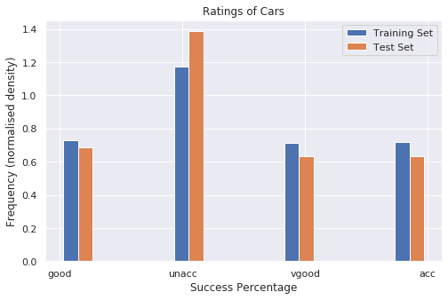

```python
# Set up a histogram for the occurences of the ratings in both the training and test sets
plt.hist([train['rating'], test['rating']], label = ["Training Set", "Test Set"], density = True)
fig = plt.gcf()
fig.set_size_inches(8, 5)
plt.legend()
plt.xlabel("Success Percentage")
plt.ylabel("Frequency (normalised density)")
plt.title("Ratings of Cars")
plt.show()
```

From the above plot, we can see that the data is slightly unbalanced as there are more cars that receive the rating unacceptable than the other ratings. However, this difference is not significant enough to justify boot-strapping, and I decided that the datasets are well balanced enough to not apply this method. Boot-strapping, the method by which we add additional samples to the data set in order to balance the data, is usually only necessary if there is a class which is severely under-represented which isn't the case here.

We can also see that the ratings are similarly distributed in the training and testing datasets.

Now, we need to organise the rating system used for the descriptor variables into a format that we can work with.

```python
# Observe the rating system used for each descriptor variable
for column in train.columns:
    print('Possible values for', column, ' ---  Train:', set(train[column]), ', Test:', set(test[column]))
```

```
Possible values for buying  ---  Train: {'low', 'med', 'high', 'vhigh'} , Test: {'high', 'low', 'vhigh', 'med'}
Possible values for maint  ---  Train: {'high', 'low', 'vhigh', 'med'} , Test: {'low', 'med', 'high', 'vhigh'}
Possible values for doors  ---  Train: {'4', '3', '2', '5more'} , Test: {'5more', '3', '2', '4'}
Possible values for persons  ---  Train: {'more', '2', '4'} , Test: {'more', '2', '4'}
Possible values for lug_boot  ---  Train: {'small', 'med', 'big'} , Test: {'small', 'med', 'big'}
Possible values for safety  ---  Train: {'low', 'high', 'med'} , Test: {'low', 'high', 'med'}
Possible values for rating  ---  Train: {'unacc', 'vgood', 'acc', 'good'} , Test: {'unacc', 'vgood', 'acc', 'good'}
```

The above shows that both the training and the test data use the same rating system for the various descriptors. Note that this also shows that the data set doesn't contain any NaN or spurious values.

Our goal now is to convert this rating system into a standard numerical scale that we can use for the various classification methods to come.

We do this by going through each descriptor and target variable, and assigning the lowest possible rating to a 0, 1 to the second lowest possible rating, and so on. For example, for the descriptor 'maint', the data set rates the price of maintenance of a car using 'low', 'med', 'high', 'vhigh'. Therefore we convert 'low' to 0, 'med' to 1, 'high' to 2, and 'vhigh' to 3.

For the target, I'm assigning the lowest possible rating, 'unacc', to 0 and the highest possible rating, 'vgood', to 3.

```python
# Original rating system
ratings_original = ['low', 'small', 'unacc',
                    'med', 'acc',
                    'high', 'big', '2', 'good',
                    'vhigh', '3', 'vgood',
                    '4',
                    '5more', 'more']

# New rating system
ratings_new = [0, 0, 0,
               1, 1,
               2, 2, 2, 2,
               3, 3, 3,
               4,
               5, 5]


for i in range(len(ratings_original)):
    # Print the progress
    print('Convert', ratings_original[i], 'to', ratings_new[i])

    # Replace ratings for the training data
    train = train.replace(to_replace = ratings_original[i], value = ratings_new[i])

    # Replace ratings for the test data
    test = test.replace(to_replace = ratings_original[i], value = ratings_new[i])
```

```
Convert low to 0
Convert small to 0
Convert unacc to 0
Convert med to 1
Convert acc to 1
Convert high to 2
Convert big to 2
Convert 2 to 2
Convert good to 2
Convert vhigh to 3
Convert 3 to 3
Convert vgood to 3
Convert 4 to 4
Convert 5more to 5
Convert more to 5
```

```python
# Observe the start of the new training set.
train.head()
```

|  | buying | maint | doors | persons | lug_boot | safety | rating |
| --- | --- | --- | --- | --- | --- | --- | --- |
| 0 | 0 | 1 | 3 | 4 | 0 | 2 | 2 |
| 1 | 3 | 3 | 2 | 2 | 0 | 0 | 2 |
| 2 | 1 | 1 | 5 | 4 | 1 | 2 | 2 |
| 3 | 0 | 1 | 3 | 4 | 0 | 2 | 0 |
| 4 | 3 | 3 | 2 | 2 | 0 | 0 | 0 |

```python
 # Observe the start of the new test set.
test.head()
```

|  | buying | maint | doors | persons | lug_boot | safety | rating |
| --- | --- | --- | --- | --- | --- | --- | --- |
| 0 | 1 | 0 | 3 | 4 | 0 | 1 | 1 |
| 1 | 0 | 0 | 2 | 5 | 2 | 1 | 2 |
| 2 | 3 | 3 | 2 | 2 | 0 | 1 | 2 |
| 3 | 0 | 0 | 2 | 5 | 2 | 1 | 0 |
| 4 | 3 | 3 | 2 | 2 | 0 | 1 | 0 |

We can also observe the distribution of the ratings for each attribute. Remember that for when we're not considering an attribute with a discrete value, e.g. doors, in general a lower value corresponds to a lower rating.

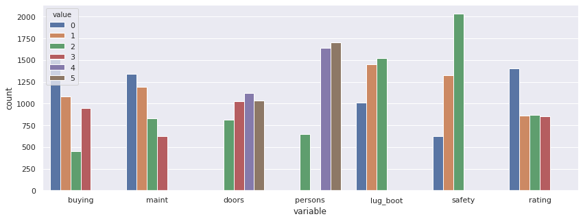

```python
# Count how often each attribute has each rating, for the training data
plt.figure(figsize = (14,5))
sns.countplot(x = 'variable', hue = 'value', data = pd.melt(train))
plt.show()
```

We'll also consider the correlations between the descriptors in the training data.

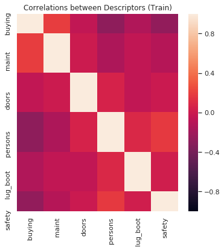

```python
# Calculate correlations in the descriptors for the training data
corr = train[descriptors].corr()
plt.figure(figsize = (6, 6))
plt.title('Correlations between Descriptors (Train)')
sns.heatmap(corr, vmin = -1, vmax = 1)
plt.show()
```

The correlation heat map shows that most descriptors do not have consistent correlations that we can derive too much meaning from. However, We can see that in particular the following descriptors are weakly positively correlated:

- Buying Price and Maintenance Cost (0.19)
- Number of Persons and Safety (0.17)

These make sense as a higher buying price should lead to a higher maintenance cost, and more people in a car will result in more provisions for safety.

The following descriptors are weakly negatively correlated:

- Buying Price and Number of Persons (-0.28)
- Buying Price and Safety (-0.27)

These correlations are more important than the others. We'll take note of this if necessary when using our models, but these correlations won't have an adverse effect on our analysis.

#### Standardisation Process

Now that we've converted the text rating system to a numerical rating system, we need to standardise the descriptors of the data set by scaling the rating system to a 0-1 scale.

In data science methods and data mining approaches, such as artificial neural networks, inputs of the **data set need to be normalized to avoid ill-conditioning**. This is done to achieve the same range of values for each of the inputs to the model we choose to use, which makes having **stable convergence of weights and biases** more likely.

Note that now we're storing the normalised data in new arrays. Instead of holding the data in two dataframes, one for testing and one for training, we're splitting them up into four arrays, two arrays for descriptors (training and testing) and two arrays for the targets (training and testing).

These new data frames are called descriptors_test, descriptors_train, target_test, target_train.

For the tasks to follow we will only use these new arrays instead of the old definitions.

Note that it's not necessary to convert the target variables, and so we leave that out here and keep them on the rating system 0, 1, 2, 3 from now on, corresponding to unacceptable, acceptable, good and very good respectively.

```python
# Standardize the data by scaling everything to a continuous 0-1 scale.

# Define the scaler
scaler = MinMaxScaler(feature_range = (0, 1))

# Apply the scaler to the test and train data
descriptors_test = scaler.fit_transform(test[descriptors])
descriptors_train = scaler.fit_transform(train[descriptors])
```

```python
# Convert the target variables into arrays for easier use in the following classification tasks
target_test = np.array(test[targets]).ravel()
target_train = np.array(train[targets]).ravel()

# Convert target data to the correct data type
target_test = target_test.astype(int)
target_train = target_train.astype(int)
```

```python
# Observe the test set for the descriptors
descriptors_test
```

```
array([[0.33333333, 0.        , 0.33333333, 0.66666667, 0.        ,
        0.5       ],
       [0.        , 0.        , 0.        , 1.        , 1.        ,
        0.5       ],
       [1.        , 1.        , 0.        , 0.        , 0.        ,
        0.5       ],
       ...,
       [0.        , 0.        , 1.        , 0.        , 0.5       ,
        1.        ],
       [0.        , 0.        , 1.        , 0.        , 1.        ,
        1.        ],
       [0.        , 0.        , 1.        , 0.66666667, 0.5       ,
        0.        ]])
```

Now we have datasets that will be easier to work with for the data science methods we wish to carry out, as the classification methods to follow make various assumptions about the data.

## Task 1: Random Forest Classifier

### Introduction and Explanation

The first classification model that we'll consider in order to classify cars in the dealership is Random Forests. Random Forests work by taking in inputs and building a number of decision trees during training, and producing a mode of the output classes of the individual trees.

We'll consider three parameters: the number of trees used, the maximum number of features considered when we split a node, and the maximum number of levels in each decision tree.

Random Forests run efficiently on large datasets, and has methods for balancing error in class populations if the dataset is not balanced properly.

### Process

In the following task, instead of giving a final black box method for classification, I'll document my exploration into random forest classification which includes specific examples and models that aren't completely optimised in order to get to our final result. This exploration is as follows:

1. Use stratified k-fold cross validation on a specific example of a random forest classifier.
2. Turn our specific example using stratified k-fold validation into a function to automatically compute mean accuracies of random forest models.
3. Instead of using our function for computing mean accuracies, we use a grid search method to optimise hyper parameters.

Note that in Task 1 and Task 2 we're using Stratified K-Fold Cross Validation which properly balances all the folds of the data set automatically, so the balancing of data sets is taken care of.

```python
#Import Random Forest Model
from sklearn.ensemble import RandomForestClassifier
```

### Simple Example of Applying Stratified 5-Fold Validation to a Random Forest

First we create a specific random forest classification system, to see what happens with the different accuracies of different splits when using stratified 5-fold validation.

This cross validation method is used to split data into training and testing data, and in this we further split the training set into 5 subsets called folds. The model is fitted iteratively 5 times, each time training on 4 of the folds and evaluated on the remaining one.

```python
# Gaussian classification model
rf_classifier_example = RandomForestClassifier(
    n_estimators = 100,
    max_depth = 6,
    max_features = 5,
    random_state = seed
)

# Set up stratified 5-fold for classification
strat_k_fold = StratifiedKFold(n_splits = 5, random_state = seed, shuffle = True)

# Keep a list for testing accuracy of each split
split_accuracies = []

# Keep track of which fold we're using
fold = 1

for training_index, testing_index in strat_k_fold.split(descriptors_train, target_train):

    # Select the descriptors and target data from the main data set - in this case the large training set
    descriptors_train_fold = descriptors_train[training_index]
    descriptors_test_fold = descriptors_train[testing_index]
    target_train_fold = target_train[training_index]
    target_test_fold = target_train[testing_index]

    # Fit the random forest classifier to the training folds
    rf_classifier_example.fit(descriptors_train_fold, target_train_fold)

    # Test the accuracy of the classifier on the testing folds
    accuracy = rf_classifier_example.score(descriptors_test_fold, target_test_fold)

    # Print out the accuracy of the classifier on this particular split
    print("Test accuracy for Fold %.d: %.3f"%(fold, accuracy))

    # Add the accuracy to the testing
    split_accuracies.append(accuracy)

    # Increase the fold number for the next loop
    fold += 1


# Print out the relevant metrics
print("Mean test accuracy: %.3f"%(np.mean(split_accuracies)))
print("Standard deviation of test accuracy: %.3f"%(np.std(split_accuracies)))
```

```
Test accuracy for Fold 1: 0.365
Test accuracy for Fold 2: 0.365
Test accuracy for Fold 3: 0.368
Test accuracy for Fold 4: 0.369
Test accuracy for Fold 5: 0.379
Mean test accuracy: 0.369
Standard deviation of test accuracy: 0.005
```

Therefore, using the specific random forest classifier defined above, we get a mean accuracy of 0.369 and a standard deviation of 0.00512 for the distribution of the accuracies of each split.

### Exploring How to Efficiently Verify Accuracy of a Random Forest

We now take our exploration above and write a function to more efficiently determine the accuracy of a classifier with given hyperparameters.

```python
# Gaussian classification model
def rf_classifier_accuracy(
    descriptors_data_input,
    target_data_input,
    n_estimators_input,
    max_depth_input,
    max_features_input,
    cv = strat_k_fold
    ):

    # Set up the data
    descriptors_data = descriptors_data_input
    target_data = target_data_input

    # Define a random forest classifier
    rf_classifier=RandomForestClassifier(
        n_estimators = n_estimators_input,
        max_depth = max_depth_input,
        max_features = max_features_input,
        random_state = seed
    )

    # Keep a list for testing accuracy of each fold
    split_accuracies = []

    for training_index, testing_index in cv.split(descriptors_data, target_data):
        # Select training and testing splits from our input data using the stratified k-fold validation
        descriptors_train = descriptors_data[training_index]
        descriptors_test = descriptors_data[testing_index]
        target_train = target_data[training_index]
        target_test = target_data[testing_index]

        # Fit the random forest to the split train data
        rf_classifier.fit(descriptors_train, target_train)

        # Calculate the accuracy of the model on the split test data
        accuracy = rf_classifier.score(descriptors_test, target_test)

        # Add the accuracy of this particular model using the split defined above to a list of accuracies
        split_accuracies.append(accuracy)

    # Compute the mean accuracy
    mean_accuracy = np.mean(split_accuracies)

    return mean_accuracy
```

Now we use the above function to compute the accuracy of the model we defined previously. Note that we get the same accuracy as before.

This function is useful as it streamlines the above process, and it doesn't print the accuracy of each split as we no longer need it.

```python
# Repeat what we did in the above but using this function, and print out the classifier's accuracy.
print('Classifier accuracy: %.3f'%(rf_classifier_accuracy(descriptors_train, target_train, 100, 6, 5)))
```

```
Classifier accuracy: 0.369
```

The goal is now to find the best hyper-parameters for this case, i.e. we need to figure out what we values we need to pick for n_estimators, max_depth, and max_features in order to get the highest accuracy our of our random forest classifier. We do this now by going through a large number of possible values for (n_estimators, max_depth, max_features) and testing out the classifier to determine their accuracies.

If we only had one hyperparameter to tune, we'd use the above function to compute the accuracy of random forests over a wide range of that parameter using a single for loop, similar to Coursework 1. However, as we're tuning our model according to multiple hyperparameters this method is insufficient if we can't assume that the hyperparameters are independent - if this was the case, we could simply tune one parameter at a time using the above method.

### Using Grid-Search to Tune Hyperparameters

The following method works by defining a range for each hyperparameter, in this case the number of trees, the maximum depth of each tree, and the maximum number of featuers to consider when splitting a node, and simply running a 5-fold cross validation on each possible combination of parameters.

The function GridSearchCV then gives us the best parameters and the corresponding accuracy score, as well as useful statistics to see what hyperparameters are most important.

```python
# Import grid searching tool for hyperparameter tuning
from sklearn.model_selection import GridSearchCV
```

```python
# Stratified 5-fold cross validation which we'll use in all further grid searches
strat_k_fold = StratifiedKFold(
    n_splits = 5,
    random_state = seed,
    shuffle = True
)

# Function for performing a grid search on a given model and set of parameters
def grid_search(
    model,
    parameters,
    cv = strat_k_fold,
    descriptors = descriptors_train,
    target = target_train
    ):


    # Fit models to each possible combination of parameters using the cross validation
    grid = GridSearchCV(
        estimator = model,
        param_grid = parameters,
        cv = cv,
        n_jobs = -1,
        scoring = 'accuracy',
        iid = True,
        verbose = 2,
        return_train_score = True
    )

    # Fit the training data to the models using grid search
    grid.fit(descriptors, target)

    # Calculate best accuracy score and the corresponding parameters
    accuracy_optimal = grid.best_score_
    parameters_optimal = grid.best_params_

    return grid, accuracy_optimal, parameters_optimal
```

```python
# Define a set of parameters to test on
rf_parameters = {
    'n_estimators': [1, 5, 10, 25, 50, 75, 100, 150, 200, 300],
    'max_depth': [1, 2, 3, 4, 5, 6, 7, 8, 9, 10, 15],
    'max_features': [1, 2, 3, 4, 5, 6]
}

# Define the classifier that we'll use in the grid search
rf_classifier = RandomForestClassifier(random_state = seed)
```

```python
rf_grid, rf_accuracy_optimal, rf_parameters_optimal = grid_search(rf_classifier, rf_parameters, cv = strat_k_fold)
```

```
Fitting 5 folds for each of 660 candidates, totalling 3300 fits
```

```
[Parallel(n_jobs=-1)]: Using backend LokyBackend with 2 concurrent workers.
[Parallel(n_jobs=-1)]: Done  56 tasks      | elapsed:    7.8s
[Parallel(n_jobs=-1)]: Done 258 tasks      | elapsed:   37.2s
[Parallel(n_jobs=-1)]: Done 606 tasks      | elapsed:  1.5min
[Parallel(n_jobs=-1)]: Done 1048 tasks      | elapsed:  2.7min
[Parallel(n_jobs=-1)]: Done 1606 tasks      | elapsed:  4.4min
[Parallel(n_jobs=-1)]: Done 2122 tasks      | elapsed:  6.1min
[Parallel(n_jobs=-1)]: Done 2665 tasks      | elapsed:  8.0min
[Parallel(n_jobs=-1)]: Done 3272 tasks      | elapsed: 10.5min
[Parallel(n_jobs=-1)]: Done 3300 out of 3300 | elapsed: 10.8min finished
```

```python
# Print the optimal accuracy and corresponding hyper parameters
print('Optimal accuracy: %.3f'%(rf_accuracy_optimal))

print('Optimal parameters')
print('- Maximum Features: %.d'%(rf_parameters_optimal['max_features']))
print('- N estimators: %.d'%(rf_parameters_optimal['n_estimators']))
print('- Maximum depth: %.d'%(rf_parameters_optimal['max_depth']))
```

```
Optimal accuracy: 0.396
Optimal parameters
- Maximum Features: 3
- N estimators: 25
- Maximum depth: 5
```

### Analysing Effect of Hyperparameters

Before continuing to a different way of classification, it's possible that some hyperparameters are having more important effects on the accuracy than others, so let's now explore this by taking all of the scores calculated for each combination of parameters in the grid search.

We start with a function to plot the mean scores of each model fit for a given hyperparameter.

```python
def plot_grid_result(
    grid,
    parameter,
    comparison = False,
    parameter_comparison = '',
    plot_training_scores = False
    ):

    # Calculate optimal parameters
    parameters_optimal = grid.best_params_

    # Compute the cross validation results
    results = grid.cv_results_

    # Put all of the scores in a dataframe and rank them
    results_dataframe = pd.DataFrame(results).sort_values(by = 'rank_test_score')

    # Return the row that contains the highest ranked score
    row_optimal = results_dataframe.iloc[0, :]

    # Get the optimal mean and parameter for the highest ranked score
    mean_optimal = row_optimal['mean_test_score']
    chosen_parameter_optimal = row_optimal['param_' + parameter]

    # Calculate the mean test scores for all possible options of the hyperparameter
    means = results_dataframe['mean_test_score']
    parameters = results_dataframe['param_' + parameter]

    if comparison:
        # Comparison parameter
        means_comparison = results_dataframe['param_' + parameter_comparison]

    plt.figure(figsize=(10, 6))

    # Plot mean train losses
    if comparison:
        plt.scatter(parameters, means, c = means_comparison, label = 'Testing Score', s = 5)
    else:
        plt.scatter(parameters, means, c = 'b', label = 'Testing Score', s = 5)

    if plot_training_scores:
        # Calculate the mean train scores for all possible options of the hyperparameter
        means_train = results_dataframe['mean_train_score']
        # Plot training losses
        plt.scatter(parameters, means_train, c = 'r', label = 'Training Score', s = 5)

    # Plot the best result
    plt.plot(chosen_parameter_optimal, mean_optimal, 'og', label = 'Optimal Testing Score')
    plt.title(parameter + ' against Score --- Optimal Score: %.3f'%(mean_optimal))
    plt.xlabel(parameter)
    plt.ylabel('Score')
    plt.legend()
    if comparison:
        cbar = plt.colorbar(label = parameter_comparison)

    plt.show()
```

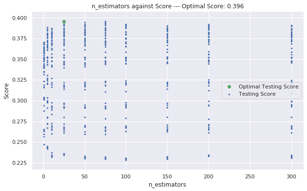

```python
# Visualise the effect of number of estimators on the accuracy score
plot_grid_result(rf_grid, 'n_estimators')
```

This plot shows that the number of estimators is not actually significantly changing the accuracy of the model in a meaningful way as we have a similar wide spread of scores across all of the different options. This indicates that some other hyperparameter is controlling the spread of the score for each n estimator value.

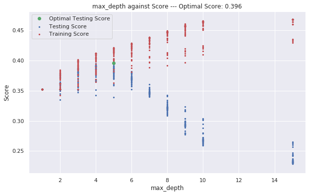

```python
# Visualise the effect of maximum depth on the accuracy score
plot_grid_result(rf_grid, 'max_depth', plot_training_scores = True)
```

Unlike the plot for n estimators, this plot shows a **clear relationship between the maximum depth and the accuracy score**. In particular, if the score seems to rise until we get to 5 for our maximum depth, and then it quickly declines.

This indicates that the maximum depth is an important hyperparameter to tune for this dataset, and we've identified a clear optimal solution for this parameter.

Given that this parameter is clearly more important to consider, I also plotted the training scores. We can see that the **model starts overfitting just as the test accuracy starts to go down** when we increase the maximum depth beyond the optimal value.

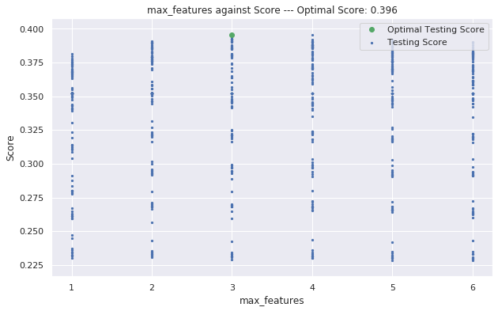

```python
# Visualise the effect of Maximum Features on the accuracy score
plot_grid_result(rf_grid, 'max_features')
```

This plot shows that the maximum number of features is not actually significantly changing the accuracy of the model in a meaningful way as we have a similar wide spread of scores across all of the different options, with a subtle peak at max_features = 3. This indicates that some other hyperparameter is controlling the spread of the score for each n estimator value, and we suspect this hyperparameter to be the maximum depth.

Below we implement a colour bar for the variable maximum depth and we can see clearly that the maximum depth is controlling the accuracy score.

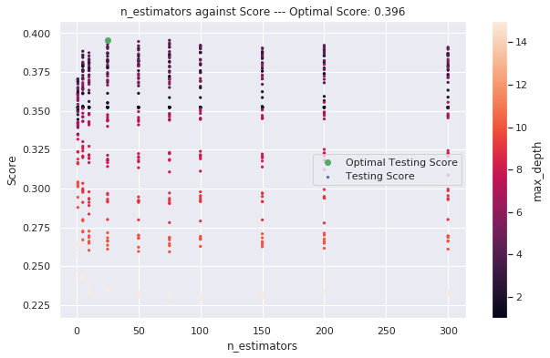

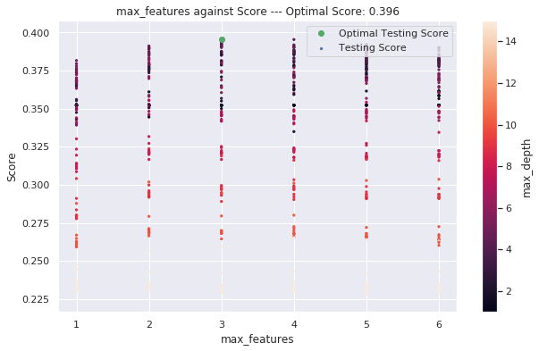

```python
# Implement colour bar to see how maximum depth controls the model
plot_grid_result(rf_grid, 'n_estimators', True, 'max_depth')
plot_grid_result(rf_grid, 'max_features', True, 'max_depth')
```

### Finer Grid Search

Now that we've identified a clear optimal value for the maximum depth, we'll perform a finer grid search for the number of estimators, n_estimators. We'll perform the same process as before but zone in on our previous best value.

As it's not computationally expensive, we also repeat the iterations over the maximum number of features but zoned in on the optimal value from the previous analysis. This is done to see any further relationships between this parameter and the accuracy score with the wider range of number of estimators.

```python
# Define a set of parameters to test on
rf_parameters_fine = {
    'n_estimators': [1, 3, 5, 7, 10, 12, 15, 17, 20, 21, 22, 23, 24, 25, 26, 27, 28, 29, 30, 31, 32, 33, 34, 35, 40, 45],
    'max_depth': [5],
    'max_features': [2, 3, 4]
}

# Define the classifier that we'll use in the grid search
rf_classifier = RandomForestClassifier(random_state = seed)
```

```python
rf_grid_fine, rf_accuracy_optimal_f, rf_parameters_optimal_f = grid_search(rf_classifier, rf_parameters_fine, cv = strat_k_fold)
```

```
Fitting 5 folds for each of 78 candidates, totalling 390 fits
```

```
[Parallel(n_jobs=-1)]: Using backend LokyBackend with 2 concurrent workers.
[Parallel(n_jobs=-1)]: Done  92 tasks      | elapsed:    4.6s
[Parallel(n_jobs=-1)]: Done 390 out of 390 | elapsed:   19.4s finished
```

```python
# Print the optimal accuracy and corresponding hyper parameters
print('Optimal accuracy: %.3f'%(rf_accuracy_optimal_f))

print('Optimal parameters')
print('- Maximum Features: %.d'%(rf_parameters_optimal_f['max_features']))
print('- N estimators: %.d'%(rf_parameters_optimal_f['n_estimators']))
print('- Maximum depth: %.d'%(rf_parameters_optimal_f['max_depth']))
```

```
Optimal accuracy: 0.396
Optimal parameters
- Maximum Features: 3
- N estimators: 25
- Maximum depth: 5
```

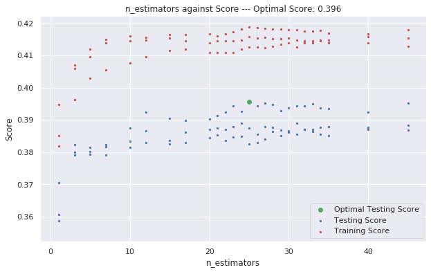

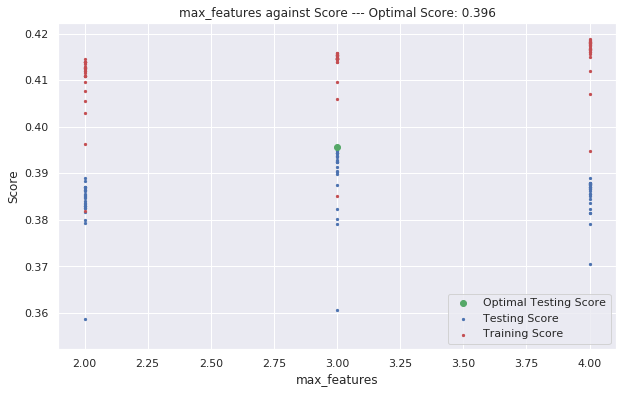

```python
# Visualise the effect of the number of estimators on the accuracy score
plot_grid_result(rf_grid_fine, 'n_estimators', plot_training_scores = True)

# Visualise the effect of the maximum number of features on the accuracy score
plot_grid_result(rf_grid_fine, 'max_features', plot_training_scores = True)
```

Further analysis using a finer grid search has not actually produced different optimal hyperparameters, but the above plot for n estimators does reveal more information about how this parameter is changing the model.

There is a quick increase from when the number of estimators is 1 up to around 10, and then the accuracy flatlines at around 25. This shows that we've picked a suitable value for our parameter of number of estimators. The training scores also show that we're not susceptible to overfitting in this case.

The second plot confirms our choice of 3 for the maximum number of features, and we can clearly see from the highest values for the training score that **increasing the maximum number of features further may lead to overfitting**.

### Optimal Model

Now we have a final model to work with using the optimal parameters defined from the grid search method. This model is what we'll use in Task 4.

```python
# Define our final random forest classification model.
rf_classifier_optimal = RandomForestClassifier(
    random_state = seed,
    max_features = rf_parameters_optimal_f['max_features'],
    n_estimators = rf_parameters_optimal_f['n_estimators'],
    max_depth = rf_parameters_optimal_f['max_depth']
    )

# Fit the model to the training data
rf_classifier_optimal = rf_classifier_optimal.fit(descriptors_train, target_train)
```

## Task 2: Support Vector Machines

### Introduction

Now we'll consider a support vector machine classification method to analyse the data set from the dealership. Support Vector Machines (SVM) find the decision boundaries to seperate the classes, minimising the errors as expected.

SVMs come in different forms. Linear SVMs find an optimal hyperplane to split up the classes, and ensure that each observation is on the correct side of hyperplane, then minimising distances from each observation to the hyperplane.

Non-Linear SVMs are used for when datasets are not linearly seperable, introducing kernels to find non-linear decision boundaries. We also consider a soft margin, where observations can be on the wrong side of the decision boundary given a certain tolerance.

How much tolerance we allow is represented by the hyperparameter 'C', with a bigger C corresponding to a bigger penalty when the model misclassifies something.

The hyperparameter 'kernel' is simply introducing non-linearity into our decision boundary, with a number of different functions that we can use such as polynomials of degree n, sigmoids, and the radial basis function (rbf).

If we choose sigmoid or rbf as our kernel, we then need to tune another hyperparameter, 'gamma'. When gamma is small, the model becomes constrained and can't analyse the complexity of the dataset. If it's too high, then the model becomes susceptible to overfitting. I've followed the convention that we fix gamma for the polynomials.

### Process

We follow a similar process to in Task 1, but we start with a function that outputs accuracy of a given SVC classifier, and then we skip straight away to using a grid search with stratified 5-fold cross validation.

```python
# Import relevant modules
from sklearn.svm import SVC
```

### Exploring how to Efficiently Evaluate Accuracy of SVM Classifiers

Similarly to what we did above, we'll start off with a function that takes in parameters and gives the accuracy of the associated SVM.

```python
def SVC_classifier_accuracy(
    descriptors_data_input,
    target_data_input,
    kernel_input,
    C_input,
    gamma_input,
    degree = 2,
    cv = strat_k_fold
    ):

    descriptors_data = descriptors_data_input
    target_data = target_data_input

    SVC_classifier = SVC(
        kernel = kernel_input,
        C = C_input,
        gamma = gamma_input,
        degree = degree,
        shrinking = True,
        tol = 1e-3,
        random_state = 0
    )

    # Keep a list for testing accuracy of each fold
    split_accuracies = []

    for training_index, testing_index in cv.split(descriptors_data, target_data):
        descriptors_train = descriptors_data[training_index]
        descriptors_test = descriptors_data[testing_index]
        target_train = target_data[training_index]
        target_test = target_data[testing_index]

        SVC_classifier.fit(descriptors_train, target_train)

        accuracy = SVC_classifier.score(descriptors_test, target_test)

        split_accuracies.append(accuracy)

    mean_accuracy = np.mean(split_accuracies)

    return mean_accuracy
```

```python
print('Classifier accuracy: %.3f'%(SVC_classifier_accuracy(descriptors_train, target_train, 'sigmoid', 1, 'auto')))
```

```
Classifier accuracy: 0.367
```

As discussed above, I would use the above function to tune the model on a single hyperparameter, or if the grid search method was computationally expensive.

### Using Grid-Search to Tune Hyperparameters

As before, we instead focus on running a grid search to iteratively fit models over a wide range of different values for the relevant hyperparameters.

```python
# Define the parameters to perform the grid search over
svc_parameters = [
    {'C': [0.1, 1, 5, 10, 25, 50, 100], 'kernel': ['linear']},
    {'C': [0.1, 1, 5, 10, 25, 50, 100], 'kernel': ['rbf'], 'gamma': [0.99, 0.75, 0.5, 0.3, 0.1, 0.01]},
    {'C': [0.1, 1, 5, 10, 25, 50, 100], 'kernel': ['sigmoid'], 'gamma': [0.99, 0.75, 0.5, 0.3, 0.1, 0.01]},
    {'C': [0.1, 1, 5, 10, 25, 50, 100], 'kernel': ['poly'], 'degree': [2, 3, 4, 5, 6, 10]}
]

# Define an instance of a SVC classifier
svc_classifier = SVC()
```

```python
svc_grid, svc_accuracy_optimal, svc_parameters_optimal = grid_search(svc_classifier, svc_parameters, cv = strat_k_fold)
```

```
Fitting 5 folds for each of 133 candidates, totalling 665 fits
```

```
[Parallel(n_jobs=-1)]: Using backend LokyBackend with 2 concurrent workers.
[Parallel(n_jobs=-1)]: Done  37 tasks      | elapsed:   20.8s
[Parallel(n_jobs=-1)]: Done 158 tasks      | elapsed:  1.8min
[Parallel(n_jobs=-1)]: Done 361 tasks      | elapsed:  4.9min
[Parallel(n_jobs=-1)]: Done 644 tasks      | elapsed:  7.4min
[Parallel(n_jobs=-1)]: Done 665 out of 665 | elapsed:  7.6min finished
```

```python
# Print the optimal accuracy and corresponding hyper parameters
print('Optimal accuracy: %.3f'%(svc_accuracy_optimal))

print('Optimal parameters')
print('- C, penalty parameter: %.3f'%(svc_parameters_optimal['C']))
print('- Kernel:', svc_parameters_optimal['kernel'])

if svc_parameters_optimal['kernel'] == 'rbf' or svc_parameters_optimal['kernel'] == 'sigmoid':
    print('- Gamma: %.3f'%(svc_parameters_optimal['gamma']))

if svc_parameters_optimal['kernel'] == 'poly':
    print(' - Degree: %.d'%(svc_parameters_optimal['degree']))
```

```
Optimal accuracy: 0.401
Optimal parameters
- C, penalty parameter: 1.000
- Kernel: rbf
- Gamma: 0.500
```

### Analysing the Effect of Hyperparameters

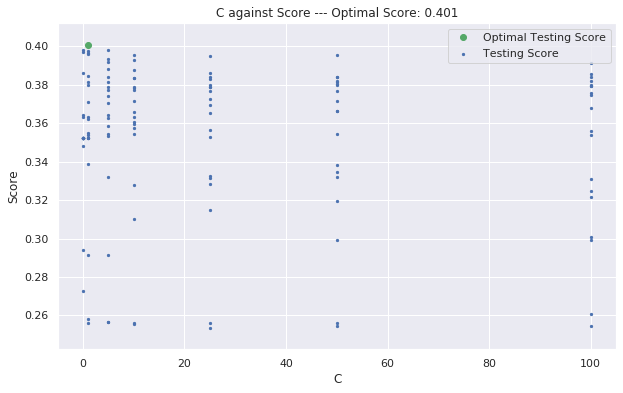

```python
# Visualise the effect of C on the accuracy score
plot_grid_result(svc_grid, 'C')
```

This plot shows that C is not actually significantly changing the accuracy of the model in a meaningful way as we have a similar wide spread of scores across all of the different options. This indicates that some other hyperparameter is controlling the spread of the score for each individual value for C. However, there is a peak at C = 1.

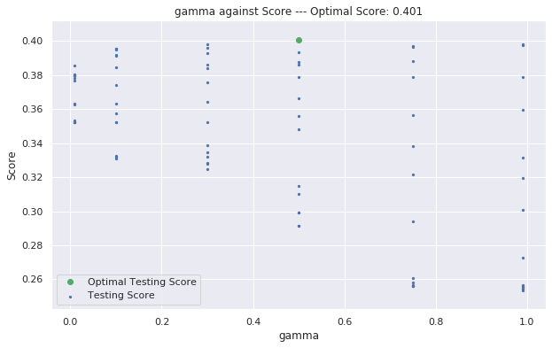

```python
# Visualise the effect of Gamma on the accuracy score
plot_grid_result(svc_grid, 'gamma')
```

This plot shows some interesting behaviour. At a first glance, the highest scores for each value of gamma seem not vary, indicating that gamma is not influencing the accuracy model in a strong way. However, we do get a slight peak at 0.5.

As gamma increases there seems to be a greater spread of scores. This indicates that the model becomes much more sensitive to the variation of the other hyperparameters as gamma gets closer to 1.

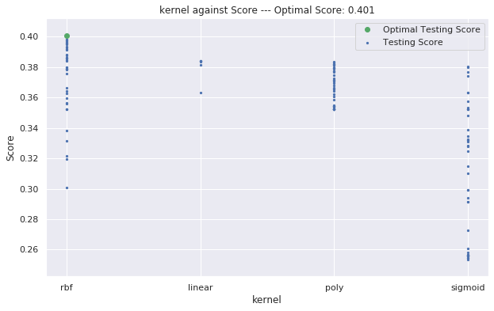

```python
# Visualise the effect of the kernel on the accuracy score
plot_grid_result(svc_grid, 'kernel')
```

The model shows some sensitivity to the choice of kernel, with a slightly **better accuracy performance when we choose our kernel as rbf**.

There's an interesting difference in the ranges of accuracies between the polynomial and the sigmoid, with this indicating that the former is less sensitive to the choice of the other hyperparameters.

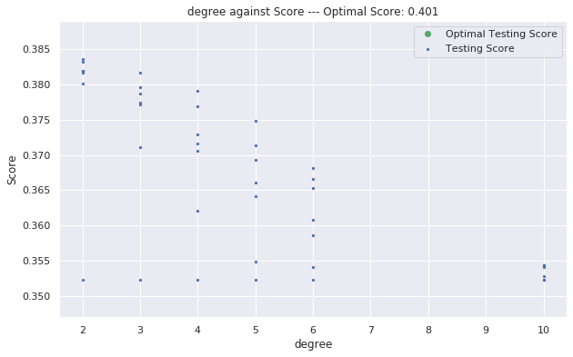

```python
# Visualise the effect of the degree on the accuracy score
plot_grid_result(svc_grid, 'degree')
```

For when we choose our kernel as the polynomial of degree n, the model is sensitive to the degree, with the highest accuracy for each degree getting smaller as n increases. Variation in accuracy is also less sensitive to other hyperparameters as n increases.

### Finer Grid Search

For the support vector machine approach we haven't been given an obvious choice of parameters to use as our optimal parameters. Therefore, I'll now run a finer grid search around the first set of tuned hyper parameters to see if we can improve model accuracy further.

We'll choose our Kernel as rbf, as this performed the best out of all the kernels in our previous grid search.

```python
# Define the parameters to perform the grid search over
svc_parameters_fine = [
    {'C': [0.1, 0.2, 0.3, 0.4, 0.5, 0.6, 0.7, 0.8, 0.9, 1, 1.1, 1.2, 1.3, 1.4, 1.5],
     'kernel': ['rbf'],
     'gamma': [0.35, 0.375, 0.4, 0.425, 0.45, 0.475, 0.5, 0.525, 0.55, 0.575, 0.6, 0.625, 0.65]},
]

# Define an instance of a SVC classifier
svc_classifier = SVC()

# Run the grid search
svc_grid_fine, svc_accuracy_optimal_f, svc_parameters_optimal_f = grid_search(svc_classifier, svc_parameters_fine, cv = strat_k_fold)
```

```
Fitting 5 folds for each of 195 candidates, totalling 975 fits
```

```
[Parallel(n_jobs=-1)]: Using backend LokyBackend with 2 concurrent workers.
[Parallel(n_jobs=-1)]: Done  37 tasks      | elapsed:   27.3s
[Parallel(n_jobs=-1)]: Done 158 tasks      | elapsed:  1.8min
[Parallel(n_jobs=-1)]: Done 361 tasks      | elapsed:  4.1min
[Parallel(n_jobs=-1)]: Done 644 tasks      | elapsed:  7.4min
[Parallel(n_jobs=-1)]: Done 975 out of 975 | elapsed: 11.2min finished
```

```python
# Print the optimal accuracy and corresponding hyper parameters
print('Optimal accuracy: %.3f'%(svc_accuracy_optimal_f))

print('Optimal parameters')
print('- C, penalty parameter: %.3f'%(svc_parameters_optimal_f['C']))
print('- Kernel:', svc_parameters_optimal_f['kernel'])
print('- Gamma: %.3f'%(svc_parameters_optimal_f['gamma']))
```

```
Optimal accuracy: 0.402
Optimal parameters
- C, penalty parameter: 0.800
- Kernel: rbf
- Gamma: 0.575
```

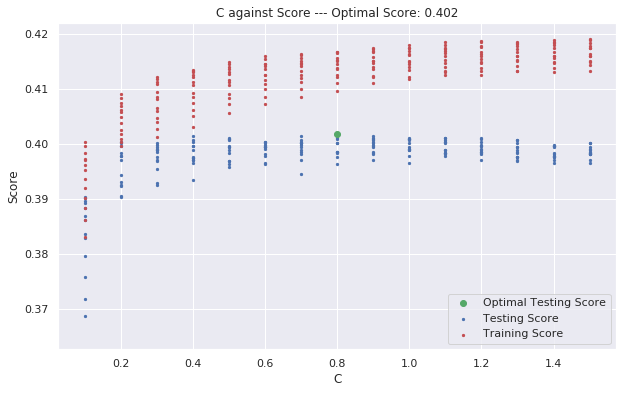

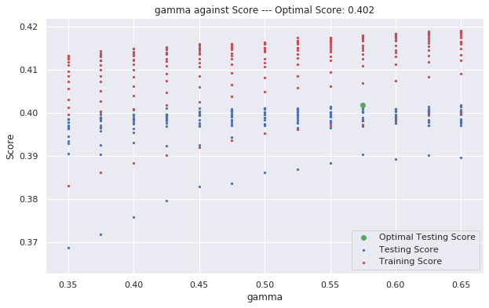

```python
# Visualise the effect of C on the accuracy score
plot_grid_result(svc_grid_fine, 'C', plot_training_scores = True)

# Visualise the effect of Gamma on the accuracy score
plot_grid_result(svc_grid_fine, 'gamma', plot_training_scores = True)
```

The above two plots confirm that neither parameter are having a considerable effect on the accuracy, but that when the cost is 0 a higher value for gamma results in a higher accuracy score, which is represented by the curved line at the bottom of the gamma vs. score plot.

We can also see that **if we used any higher values for the cost or for gamma this may lead to overfitting, particularly for gamma**.

Fine tuning the model in this way has only slightly increased the accuracy, increasing from 0.401 to 0.402. But this extra analysis was useful in identifying how the variation of parameters was changing the model.

### Optimal SVM

```python
# Define the classifier using the optimal parameters
svc_classifier_optimal = SVC(
    kernel = svc_parameters_optimal['kernel'],
    C = svc_parameters_optimal['C'],
    gamma = svc_parameters_optimal['gamma'],
    shrinking = True,
    tol = 1e-3,
    random_state = 0
)

# Fit the model
svc_classifier_optimal = svc_classifier_optimal.fit(descriptors_train, target_train)
```

## Task 3: Neural Networks

### Introduction

Now we come to our final idea for how to classify the cars in the dealership using data science methods: Neural Networks.

Neural Networks are designed to recognise patterns, and make predictions based on a number of algorithms and linear algebra. Neural Networks predict mainly using a method called **backpropagation**, which is basically a mechanism through which the network learns about errors that it's making when making predictions. When a network is first created it has no knowledge and so makes guesses randomly, but then these guesses become more finely tuned as the network is trained on data.

When a data instance is passed through the network, or propagated forward, a prediction is made, and then the error can be measured and passed backwards. The network then uses this error to reset its weights and parameters, in the direction of where there is less error using gradient descent.

In our case, we start with 6 nodes to describe the cars, and then we want to pass this information through a series of nodes with weights assigned to them. The information exits the network into target variables, in our case one of four classes: unacceptable, acceptable, good and very good. We then train our network over a series of epochs to increase the likelihood of an unseen bit of data getting assigned to the correct classification.

Below see a schematic of the first network that we'll design, which has **2 hidden layers with 200 neurons each**.

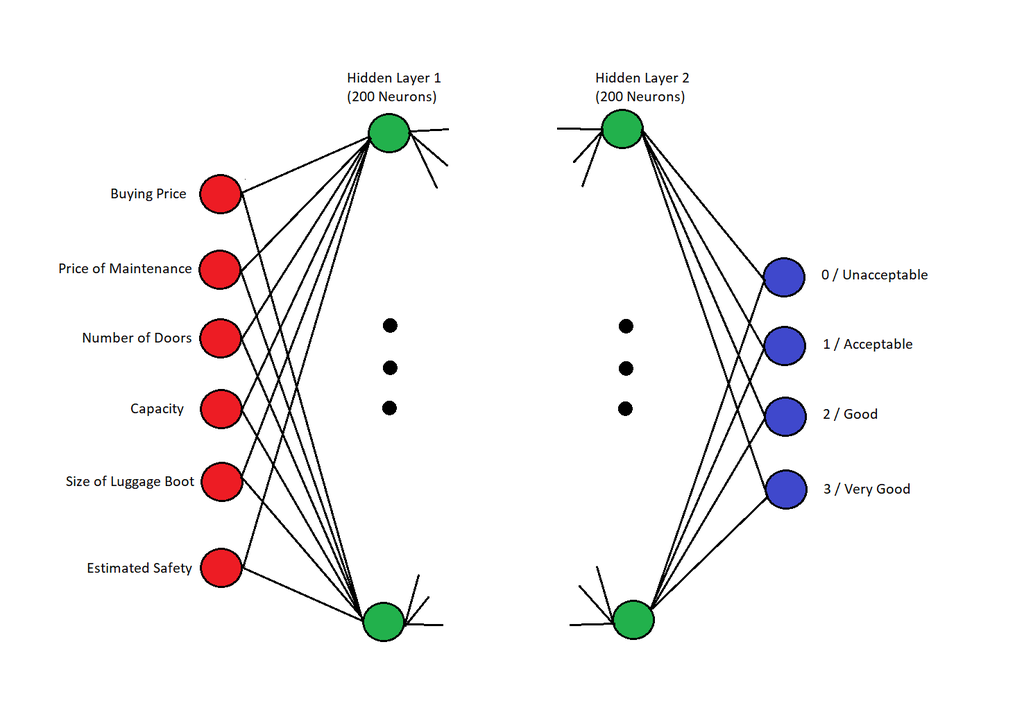

```python
from IPython.display import Image
Image("/content/drive/My Drive/Colab Notebooks/Data Science Coursework 2/Neural Network Example.png", width = 700)
```

### Import Packages

```python
# Import packages from Facebook's Neural Network package, PyTorch
import torch
import torch.nn as nn
import torch.utils.data
import torch.nn.functional as F
from torch import cuda
from sklearn.model_selection import train_test_split

# Initialise variables
batch_size = 64
learning_rate = 0.05
num_epochs = 120
```

### Hyperparameters for the Neural Network

Before starting, let's consider the hyperparameters of the neural network that we'll build.

`input_size`: # nodes per input layer of the neural network. In our case this will be 6 as we have 6 descriptors.

`num_classes`: # of classes in the target variable. In our case this will be 4 as we have 4 possible rankings: unacceptable, acceptable, good and very good.

`hidden_size`: # neurons per hidden layer.

`num_epochs`: # epochs for training.

`batch_size`: # examples that network observes before updating weights. This controls the number of training samples that the model considers before changing weights.

`learning_rate`: backpropagation learning rate. This is the amount of change that the model makes during each step of the training process. This is one of the most important hyperparameters to tune. If the learning rate is 0.1, then weights are updated by 10% of the estimated weight error each time weights are updated.

We'll set up all these parameters below.

### Preparation of the Data

Before continuing we need to prepare the data sets for the neural network.

We need to define a tensor data set and a loader for the data. The tensor data set turns the data into a tensor, and the data loader splits it up into batches. These batches then go into the neural network one at a time.

```python
# Everything in PyTorch is done using tensors, which is why we convert them to this format here to then use tensors afterwards

def load_data(descriptors_input, target_input):
    # Convert the raw numpy data into a format that can be used by PyTorch
    descriptors = torch.from_numpy(descriptors_input).float()
    target = torch.from_numpy(target_input)
    return descriptors, target

def load_tensors(descriptors_input, target_input):
    # Convert to the tensor format
    data = torch.utils.data.TensorDataset(descriptors_input, target_input)
    return data

def load_data_and_tensors(descriptors_input, target_input):
    # Complete the complete loading of data process
    descriptors, target = load_data(descriptors_input, target_input)
    data = load_tensors(descriptors, target)
    return data

# Define a function for setting up the loaders for the data sets
def get_loaders(batch_size_input, train_input, test_input):
    train_loader = torch.utils.data.DataLoader(train_input, batch_size = batch_size_input)
    test_loader = torch.utils.data.DataLoader(test_input, batch_size = batch_size_input)
    return train_loader, test_loader

# A function specifically for converting arrays for descriptor and target data into a test loader.
# This provides a nice short cut for one of our testing functions later on.
def get_test_loader_from_arrays(batch_size, descriptors_test, target_test):
    test_data = load_data_and_tensors(descriptors_test, target_test)
    test_loader = torch.utils.data.DataLoader(test_data, batch_size)
    return test_loader
```

### Using the GPU

It can be advantageous to use the GPU when training the neural network, so here we define the device to be used in the training.

```python
# Set up the device to be used in the neural network training
# If it's available, the GPU will be used
dev = 'cuda' if cuda.is_available() else 'cpu'
```

### Set up the Neural Network

Here we define a general class for a neural network.

Note that we include dropout regularisation at the second layer, but that the default dropout rate is 0, and so this wont affect Tasks 3.1 and 3.2 where we don't want to include this.

```python
# Define the neural network with dropout
class NeuralNet(nn.Module):
    def __init__(self, input_size, hidden_size, num_classes, dropout_rate = 0):
        super(NeuralNet, self).__init__()

        self.input_size = input_size
        self.hidden_size = hidden_size
        self.num_classes = num_classes
        self.dropout_rate = dropout_rate

        self.layer1 = nn.Linear(input_size, hidden_size)
        self.dropout = nn.Dropout(dropout_rate)
        self.layer2 = nn.Linear(hidden_size, hidden_size)
        self.layer3 = nn.Linear(hidden_size, num_classes)

    def forward(self, x):
        # Use ReLU as the activation function

        # Apply ReLU to x
        x = F.relu(self.layer1(x))
        x = self.dropout(x)
        x = F.relu(self.layer2(x))
        x = self.layer3(x)
        # No final softmax as it's included in CrossEntropyLoss
        return x

# When we're using a trained model with drop-out to predict, make sure we're in evaluation mode
# Then, PyTorch automatically turns off the drop-out
```

To make our process generalisable later on, we define a function that returns a neural network with given parameters.

```python
# A function for defining neural networks
def get_network(input_size_input, hidden_size_input, num_classes_input, dropout_rate = 0):
    network = NeuralNet(input_size, hidden_size, num_classes, dropout_rate)
    return network
```

### Criterion and Optimiser

For our model we need a loss function to estimate the performance of our classification model, and an optimisation method to use in the back-propagation.

Here we use cross entropy loss, and our optimisation is stochastic gradient descent which is an iterative method for finding the minimisation of the loss function.

Note that stochastic gradient descent can be noisy, but it's easy to compute.

```python
# A function for defining a stochastic gradient descent optimiser
def optimiser_SGD(network_input, learning_rate_input):
    optimiser_SGD = torch.optim.SGD(network_input.parameters(), lr = learning_rate_input)
    return optimiser_SGD

# Define the loss function, in this case Cross Entropy Loss
# Note that I've decided not to turn this into a function as the only criterion we'll use in this coursework is Cross Entropy Loss
criterion_CEP = nn.CrossEntropyLoss()
```

### Testing a Neural Network

We'll define a function which takes in a neural network and it's test loader, and it'll return the accuracy of the network.

Note that we're defining testing functions here first, and below we'll define a training function afterwards.

```python
# Given a neural network and a test loader, compute the predicted values
def neural_network_predict(trained_network, test_loader):

    # Put the network into evaluation mode
    trained_network.eval()

    # Initialize the prediction and label lists into tensors
    y_preds = torch.zeros(0, dtype = torch.long, device = dev)
    y_true = torch.zeros(0, dtype = torch.long, device = dev)

    for (x, y) in test_loader:
        # Use the GPU if it's available
        x = x.to(dev)
        y = y.to(dev)

        # Use the network to predict target variables
        y_pred = trained_network(x)
        _, predicted = torch.max(y_pred.data, 1)

        # Add on results from batch prediction
        y_preds = torch.cat([y_preds, predicted.view(-1).cpu()])
        y_true = torch.cat([y_true, y.view(-1).cpu()])

    # y values into numpy format
    y_pred_output = y_preds.numpy()
    y_true_output = y_true.numpy()

    return y_pred_output, y_true_output
```

```python
def neural_network_accuracy(trained_network, test_loader):
    y_pred, y_true = neural_network_predict(trained_network, test_loader)
    accuracy = accuracy_score(y_pred, y_true)
    return accuracy
```

### Training a General Neural Network

Below is a process for training a general neural network.

```python
def neural_network_training(
        network,
        descriptors = descriptors_train,
        targets = target_train,
        epochs = num_epochs,
        learning_rate = learning_rate,
        batch_size = batch_size,
        criterion = criterion_CEP,
        print_loss_values = True,
        print_intermediate_loss_values = False,
        print_iteration_interval = 1,
        split_and_test = False,
        seed = seed
    ):

    # Set aside a portion of the data to use for in-sample testing
    if split_and_test:
        X_train, X_test, y_train, y_test = train_test_split(descriptors, targets, test_size = 0.2, random_state = seed)
    else:
        X_train = descriptors
        y_train = targets
        X_test = np.array([])
        y_test = np.array([])

    # Load our entire data set into the correct format
    train = load_data_and_tensors(X_train, y_train)
    test = load_data_and_tensors(X_test, y_test)

    # Set up initial loaders
    train_loader, test_loader = get_loaders(batch_size, train, test)

    # Optimiser
    optimiser = optimiser_SGD(network, learning_rate)

    total_step = len(train_loader)
    num_elements = len(X_train)

    loss_values = []

    accuracies = []

    for epoch in range(epochs + 1):

        network.train()

        train_loss = 0

        for index, (x, y) in enumerate(train_loader):

            # Use the GPU if it's available
            x = x.to(dev)
            y = y.to(dev)

            # Forward pass
            y_pred = network(x)
            loss = criterion(y_pred, y)

            # Backward pass and optimisation
            optimiser.zero_grad()
            loss.backward()

            # Update weights
            optimiser.step()

            # Update the loss
            train_loss += (loss.item() * len(y)) / num_elements

            # Print out statistics within the epoch
            if index % print_iteration_interval == 0 and print_loss_values and print_intermediate_loss_values:
                print('Epoch [%.d / %.d] - Iteration [%.d / %.d] - Training Loss: %.3f'%(epoch, epochs, index, total_step, train_loss))

        if print_loss_values:
            # Print out the statistics for each epoch
            print('EPOCH COMPLETE - EPOCH [%.d / %.d] - TRAINING LOSS FOR EPOCH: %.3f'%(epoch, epochs, train_loss))

        # Add training loss to list of training losses
        loss_values.append(train_loss)

        # Calculate accuracy of the model after this epoch using the in-sample data set aside
        if split_and_test:
            # Evaluate the accuracy of the network at the end of this epoch
            accuracy = neural_network_accuracy(network, test_loader)
            accuracies.append(accuracy)

    if print_loss_values:
        print('Training completed!')

    return loss_values, accuracies, network
```

### Testing a Neural Network with Cross Validation

Now we implement a more advanced method for testing a neural network, which incorporates stratified k-fold cross validation.

Note that this is very similar to what we've done previously with other models.

```python
def neural_network_accuracy_cv(
        network,
        cv,
        descriptors = descriptors_train,
        target = target_train,
        batch_size = batch_size,
        learning_rate = learning_rate
    ):

    # Keep a list for testing accuracy of each fold
    split_accuracies = []

    for training_index, testing_index in cv.split(descriptors, target):

        descriptors_train_split = descriptors[training_index]
        target_train_split = target[training_index]

        descriptors_test_split = descriptors[testing_index]
        target_test_split = target[testing_index]

        _, _, network = neural_network_training(
            network,
            descriptors = descriptors_train_split,
            targets = target_train_split,
            learning_rate = learning_rate,
            batch_size = batch_size,
            print_loss_values = False,
            split_and_test = False
        )

        test_loader = get_test_loader_from_arrays(batch_size, descriptors_test_split, target_test_split)

        accuracy = neural_network_accuracy(network, test_loader)

        split_accuracies.append(accuracy)

        mean_accuracy = np.mean(split_accuracies)

    return mean_accuracy
```

### Example of Training a Neural Network

So now we giving an example of training a neural network on the training data. We'll refer to this neural network as our base network.

```python
%%time
# Fix the parameters that are chosen according to our data set/
# These always stay the same as we have 6 descriptor variables and 4 ways of classifying the cars
input_size = 6
num_classes = 4

# Define the hyperparameters that we're gonna use in the following analysis
hidden_size = 200
num_epochs = 120
batch_size = 64
learning_rate = 0.05

# Set up the first network example
network_base = get_network(input_size, hidden_size, num_classes)

# Calculate losses, accuracies and return the trained network
loss_base, accuracies_base, network_base = neural_network_training(
    network_base,
    batch_size = batch_size,
    learning_rate = learning_rate,
    print_loss_values = True,
    split_and_test = True
    )
```

```
EPOCH COMPLETE - EPOCH [0 / 120] - TRAINING LOSS FOR EPOCH: 1.360
EPOCH COMPLETE - EPOCH [1 / 120] - TRAINING LOSS FOR EPOCH: 1.341
EPOCH COMPLETE - EPOCH [2 / 120] - TRAINING LOSS FOR EPOCH: 1.325
EPOCH COMPLETE - EPOCH [3 / 120] - TRAINING LOSS FOR EPOCH: 1.314
EPOCH COMPLETE - EPOCH [4 / 120] - TRAINING LOSS FOR EPOCH: 1.305
EPOCH COMPLETE - EPOCH [5 / 120] - TRAINING LOSS FOR EPOCH: 1.298
EPOCH COMPLETE - EPOCH [6 / 120] - TRAINING LOSS FOR EPOCH: 1.293
EPOCH COMPLETE - EPOCH [7 / 120] - TRAINING LOSS FOR EPOCH: 1.289
EPOCH COMPLETE - EPOCH [8 / 120] - TRAINING LOSS FOR EPOCH: 1.285
EPOCH COMPLETE - EPOCH [9 / 120] - TRAINING LOSS FOR EPOCH: 1.281
EPOCH COMPLETE - EPOCH [10 / 120] - TRAINING LOSS FOR EPOCH: 1.278
EPOCH COMPLETE - EPOCH [11 / 120] - TRAINING LOSS FOR EPOCH: 1.274
EPOCH COMPLETE - EPOCH [12 / 120] - TRAINING LOSS FOR EPOCH: 1.271
EPOCH COMPLETE - EPOCH [13 / 120] - TRAINING LOSS FOR EPOCH: 1.268
EPOCH COMPLETE - EPOCH [14 / 120] - TRAINING LOSS FOR EPOCH: 1.265
EPOCH COMPLETE - EPOCH [15 / 120] - TRAINING LOSS FOR EPOCH: 1.262
EPOCH COMPLETE - EPOCH [16 / 120] - TRAINING LOSS FOR EPOCH: 1.259
EPOCH COMPLETE - EPOCH [17 / 120] - TRAINING LOSS FOR EPOCH: 1.256
EPOCH COMPLETE - EPOCH [18 / 120] - TRAINING LOSS FOR EPOCH: 1.253
EPOCH COMPLETE - EPOCH [19 / 120] - TRAINING LOSS FOR EPOCH: 1.250
EPOCH COMPLETE - EPOCH [20 / 120] - TRAINING LOSS FOR EPOCH: 1.247
EPOCH COMPLETE - EPOCH [21 / 120] - TRAINING LOSS FOR EPOCH: 1.245
EPOCH COMPLETE - EPOCH [22 / 120] - TRAINING LOSS FOR EPOCH: 1.242
EPOCH COMPLETE - EPOCH [23 / 120] - TRAINING LOSS FOR EPOCH: 1.240
EPOCH COMPLETE - EPOCH [24 / 120] - TRAINING LOSS FOR EPOCH: 1.237
EPOCH COMPLETE - EPOCH [25 / 120] - TRAINING LOSS FOR EPOCH: 1.235
EPOCH COMPLETE - EPOCH [26 / 120] - TRAINING LOSS FOR EPOCH: 1.233
EPOCH COMPLETE - EPOCH [27 / 120] - TRAINING LOSS FOR EPOCH: 1.231
EPOCH COMPLETE - EPOCH [28 / 120] - TRAINING LOSS FOR EPOCH: 1.228
EPOCH COMPLETE - EPOCH [29 / 120] - TRAINING LOSS FOR EPOCH: 1.226
EPOCH COMPLETE - EPOCH [30 / 120] - TRAINING LOSS FOR EPOCH: 1.225
EPOCH COMPLETE - EPOCH [31 / 120] - TRAINING LOSS FOR EPOCH: 1.223
EPOCH COMPLETE - EPOCH [32 / 120] - TRAINING LOSS FOR EPOCH: 1.221
EPOCH COMPLETE - EPOCH [33 / 120] - TRAINING LOSS FOR EPOCH: 1.219
EPOCH COMPLETE - EPOCH [34 / 120] - TRAINING LOSS FOR EPOCH: 1.218
EPOCH COMPLETE - EPOCH [35 / 120] - TRAINING LOSS FOR EPOCH: 1.216
EPOCH COMPLETE - EPOCH [36 / 120] - TRAINING LOSS FOR EPOCH: 1.215
EPOCH COMPLETE - EPOCH [37 / 120] - TRAINING LOSS FOR EPOCH: 1.214
EPOCH COMPLETE - EPOCH [38 / 120] - TRAINING LOSS FOR EPOCH: 1.212
EPOCH COMPLETE - EPOCH [39 / 120] - TRAINING LOSS FOR EPOCH: 1.211
```

[output cut: 69 more lines]

```
EPOCH COMPLETE - EPOCH [109 / 120] - TRAINING LOSS FOR EPOCH: 1.180
EPOCH COMPLETE - EPOCH [110 / 120] - TRAINING LOSS FOR EPOCH: 1.180
EPOCH COMPLETE - EPOCH [111 / 120] - TRAINING LOSS FOR EPOCH: 1.180
EPOCH COMPLETE - EPOCH [112 / 120] - TRAINING LOSS FOR EPOCH: 1.180
EPOCH COMPLETE - EPOCH [113 / 120] - TRAINING LOSS FOR EPOCH: 1.179
EPOCH COMPLETE - EPOCH [114 / 120] - TRAINING LOSS FOR EPOCH: 1.179
EPOCH COMPLETE - EPOCH [115 / 120] - TRAINING LOSS FOR EPOCH: 1.179
EPOCH COMPLETE - EPOCH [116 / 120] - TRAINING LOSS FOR EPOCH: 1.179
EPOCH COMPLETE - EPOCH [117 / 120] - TRAINING LOSS FOR EPOCH: 1.179
EPOCH COMPLETE - EPOCH [118 / 120] - TRAINING LOSS FOR EPOCH: 1.178
EPOCH COMPLETE - EPOCH [119 / 120] - TRAINING LOSS FOR EPOCH: 1.178
EPOCH COMPLETE - EPOCH [120 / 120] - TRAINING LOSS FOR EPOCH: 1.178
Training completed!
CPU times: user 10.1 s, sys: 243 ms, total: 10.4 s
Wall time: 10.9 s
```

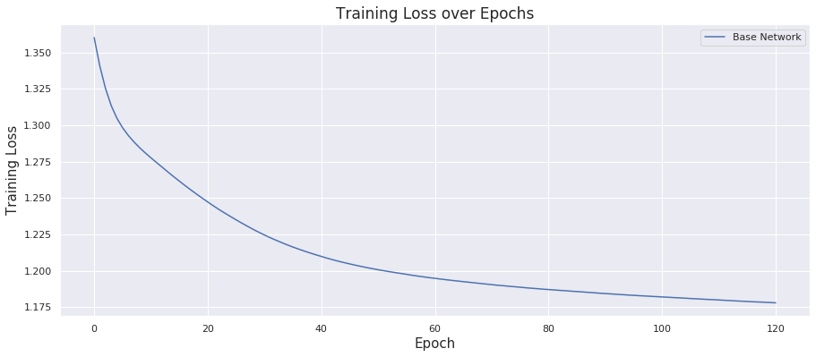

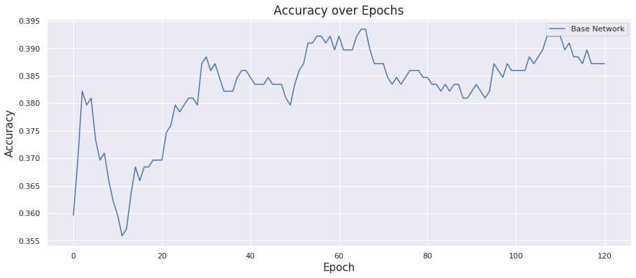

```python
# General plotting function
def plot_stats(data, labels, title, ylabel):
    plt.figure(figsize = (15,6))
    plt.autoscale(True, axis = 'both')
    plt.ylabel(ylabel, fontsize = 15)
    plt.xlabel('Epoch', fontsize = 15)
    plt.title(title, fontsize = 17)
    for i in range(len(data)):
        plt.plot(data[i])
    plt.legend(labels)
    plt.show()

plot_stats([loss_base], ['Base Network'], 'Training Loss over Epochs', 'Training Loss')
plot_stats([accuracies_base], ['Base Network'], 'Accuracy over Epochs', 'Accuracy')
```

Here the training loss is describing how poorly the model performs after each optimisation process, and in general with each epoch the model improves.

The accuracy in this plot, and all plots to follow, refers to the accuracy of the model after each epoch which is calculated using a portion of in-sample data that we set aside at the start of the training session which isn't used in the training process. As expected, the accuracy generally increases as we reach higher iterations, with it trailing off as we reach the end of the cycle.

### Setting up a Process for Experimenting with Neural Networks

Before continuing to the tasks 3.1 and 3.2, where we need to set up and train neural networks with different batch sizes and learning rates, I'm going to streamline the above process into a function that we can call to easily manipulate these two parameters and see what our loss values are.

```python
def get_trained_neural_network(
    batch_size = batch_size,
    learning_rate = learning_rate,
    dropout_rate = 0,
    split_and_test = False
    ):

    network = get_network(input_size, hidden_size, num_classes, dropout_rate)

    loss, accuracies, network_trained = neural_network_training(
        network,
        batch_size = batch_size,
        learning_rate = learning_rate,
        print_loss_values = False,
        split_and_test = split_and_test
        )

    return loss, accuracies, network
```

### Task 3.1 - Learning Rate

We'll use the function get_trained_neural_network to observe how the loss values and the loss convergence change according to different learning rates.

```python
%%time
# Calculate losses and accuracies for a network with learning rate 0.0005
loss_2, accuracies_2, _ = get_trained_neural_network(64, 0.0005, split_and_test = True)
```

```
CPU times: user 9.77 s, sys: 277 ms, total: 10 s
Wall time: 10.2 s
```

```python
%%time
# Calculate losses and accuracies for a network with learning rate 0.15
loss_3, accuracies_3, _ = get_trained_neural_network(64, 0.15, split_and_test = True)
```

```
CPU times: user 9.74 s, sys: 266 ms, total: 10 s
Wall time: 10.1 s
```

```python
%%time
# Calculate losses and accuracies for a netwrok with learning rate 0.95
loss_4, accuracies_4, _ = get_trained_neural_network(64, 0.95, split_and_test = True)
```

```
CPU times: user 9.82 s, sys: 246 ms, total: 10.1 s
Wall time: 10.2 s
```

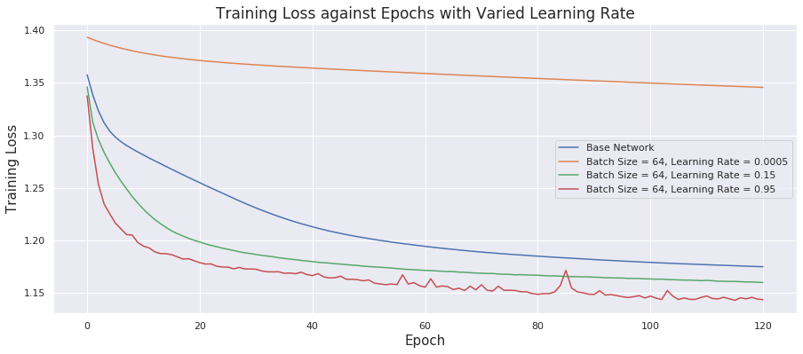

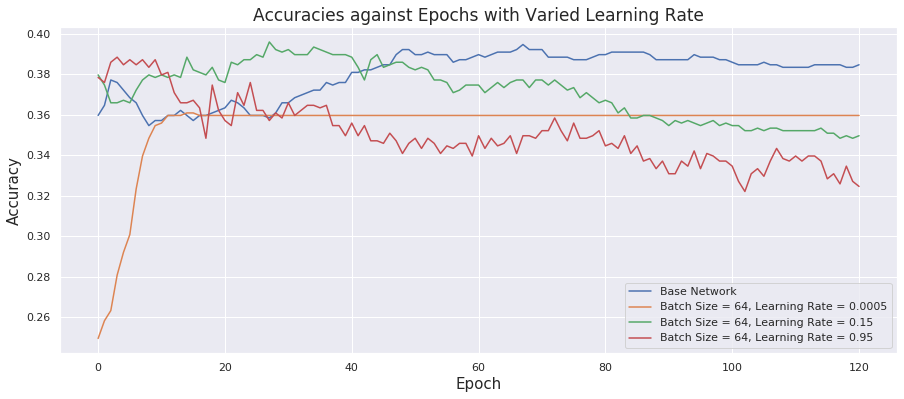

```python
# Plot the loss values against epochs
plot_stats(
    [loss_base, loss_2, loss_3, loss_4],
    ['Base Network',
     'Batch Size = 64, Learning Rate = 0.0005',
     'Batch Size = 64, Learning Rate = 0.15',
     'Batch Size = 64, Learning Rate = 0.95'
     ],
    'Training Loss against Epochs with Varied Learning Rate',
    'Training Loss'
    )

# Plot the accuracies against epochs
plot_stats(
    [accuracies_base, accuracies_2, accuracies_3, accuracies_4],
    ['Base Network',
     'Batch Size = 64, Learning Rate = 0.0005',
     'Batch Size = 64, Learning Rate = 0.15',
     'Batch Size = 64, Learning Rate = 0.95'
     ],
    'Accuracies against Epochs with Varied Learning Rate',
    'Accuracy'
    )
```

In the above, our model produces a lower training loss as the learning rate gets higher. However, this is due to **over-fitting on the training data**, and so it's more appropriate to find a balance between training loss and the **minimisation of overfitting**.

The **higher learning rate here is letting the neural network train quicker as shown by the high initial accuracy** when compared to our model with the lowest training rate, but the final weights aren't going to be optimal and generalisable to out of sample data. This **higher learning rate leads to bigger jumps in our parameter settings within the network**.

Also, when learning rate is high enough the optimisation method can make the training loss increase instead of decrease with increasing epochs, which is what we see at the highest learning rate in the plot above of 0.95 with a less smooth curve.

When the learning rate is smaller, the neural network might take longer to train but it will more likely produce weights that are better and more generalisable. However in our above calculations we can see that the learning rate isn't actually drastically changing the training time in this case, though with more computational power we would train the network for a longer time with lower learning rates to ensure a high enough accuracy.

We can see this effect above, with a very lower training rate producing models with comparitively very lower accuracy in the first 10 epochs. Even when the model in this case reaches a higher accuracy after 10 epochs, its low training rate is then not allowing it to reach a higher accuracy as the epochs go on like the other models.

With more computational power we'd also consider **variable learning rates**.

### Task 3.2 - Batch Size

We'll use the function get_trained_neural_network to observe how the loss values and the loss convergence change according to different batch sizes.

```python
%%time
# Calculate the losses and accuracies for a neural network with batch size 2
loss_5, accuracies_5, _ = get_trained_neural_network(2, 0.05, split_and_test = True)
```

```
CPU times: user 2min 23s, sys: 8.19 s, total: 2min 31s
Wall time: 2min 32s
```

```python
%%time
# Calculate the losses and accuracies for a neural network with batch size 100
loss_6, accuracies_6, _ = get_trained_neural_network(100, 0.05, split_and_test = True)
```

```
CPU times: user 8.3 s, sys: 156 ms, total: 8.46 s
Wall time: 8.58 s
```

```python
%%time
# Calculate the losses and accuracies for a neural network with batch size 256
loss_7, accuracies_7, _ = get_trained_neural_network(256, 0.05, split_and_test = True)
```

```
CPU times: user 6.72 s, sys: 94.5 ms, total: 6.81 s
Wall time: 6.89 s
```

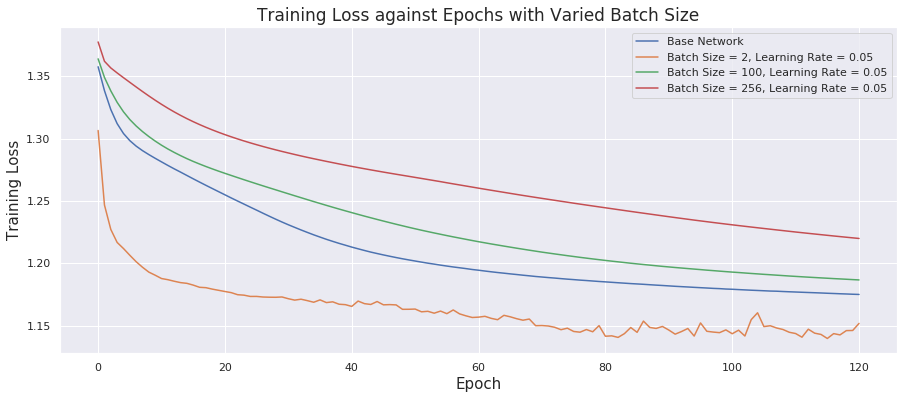

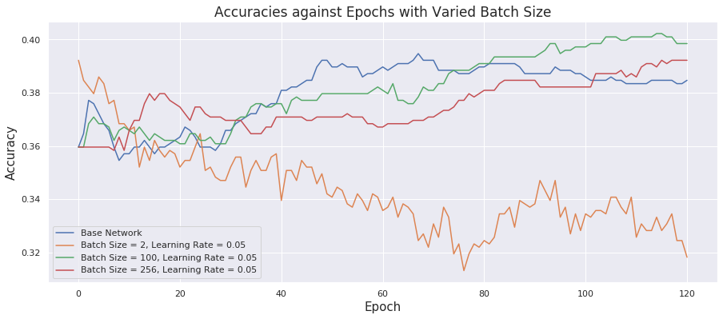

```python
# Plot the loss values against epochs
plot_stats(
    [loss_base, loss_5, loss_6, loss_7],
    ['Base Network',
     'Batch Size = 2, Learning Rate = 0.05',
     'Batch Size = 100, Learning Rate = 0.05',
     'Batch Size = 256, Learning Rate = 0.05'
     ],
    'Training Loss against Epochs with Varied Batch Size',
    'Training Loss'
    )

# Plot the accuracies against epochs
plot_stats(
    [accuracies_base, accuracies_5, accuracies_6, accuracies_7],
    ['Base Network',
     'Batch Size = 2, Learning Rate = 0.05',
     'Batch Size = 100, Learning Rate = 0.05',
     'Batch Size = 256, Learning Rate = 0.05'
     ],
    'Accuracies against Epochs with Varied Batch Size',
    'Accuracy'
    )
```

In the above plot we can see that as the batch size decreases the training loss reached after 120 epochs decreases.

Remember that batch size is the number of samples that the network will consider before updating the internal weights.

**Smaller batches have a quicker convergence to a workable solution**, which is intuitive given that smaller sizes mean the model learns with a smaller amount of data. But this comes with the issue of a **higher likelihood of not getting to a global optimal solution**. This is displayed above as when we have a batch size of 2, the model starts off with the highest in-sample accuracy when compared to the other models, but then this very quickly trails off as the model isn't able to train as well as the other models with higher batch sizes.

Having a **small batch size is also computationally incredibly expensive** as the training process is having to iterate through a very high number of small batches, and leads to a high training time as can be seen above. This is shown by the CPU times printed above.

It's also possible to **make up for a lower batch size by giving the network a higher learning rate**.

### Task 3.3 - Dropout Regularisation

In this task we'll consider a parameter that we can actually tune similarly to in Tasks 1 and 2, namely a drop out rate. We'll implement a drop out rate into the second layer of the neural network which essentially turns off weights for neurons at a given rate - this is done to prevent overfitting. This gives a slightly noisier training process, which **makes the network more robust to overfitting and means it will be more generalisable to out of sample data**.

Note that in the definition of our class for NeuralNetwork, we've included dropout regularisation to the second layer of the network - the automatic value for the dropout rate is 0, and so this feature has been turned off in all of the above tasks. However, now we can attempt to tune the hyperparameter of the dropout rate to optimise our Neural Network. We do this using 5-fold cross validation as done in Task 1 and Task 2.

As we've got a single hyperparameter to tune, we'll use the simple method that we described previously of testing models with a wide range of dropout rate values, and choose the one which gives us the optimised model as the network to use in any further tasks.

In the function below, we use our previously defined functions for testing a neural network to tune the dropout rate.

```python
def tune_dropout_rate(start = 0, end = 1, fineness = 10, print_progress = False):

    # Set up the range of parameters to test over
    dropout_parameters = np.linspace(start, end, fineness)

    # Accuracies
    accuracies = []

    # Set up stratified 5-fold for classification
    strat_kfold = StratifiedKFold(n_splits = 5, random_state = 10, shuffle=True)

    for dropout_rate in dropout_parameters:

        network = get_network(input_size, hidden_size, num_classes, dropout_rate = dropout_rate)

        # Calculate the accuracy of the network using stratified 5-fold cross validation
        accuracy = neural_network_accuracy_cv(
            network = network,
            batch_size = batch_size,
            learning_rate = learning_rate,
            cv = strat_kfold
        )

        # Update accuracies
        accuracies.append(accuracy)

        # Print progress
        if print_progress:
            print('Dropout Rate = %.3f, Accuracy = %.3f'%(dropout_rate, accuracy))

    accuracy_optimal = max(accuracies)
    dropout_rate_optimal = dropout_parameters[np.argmax(accuracies)]

    return dropout_rate_optimal, accuracy_optimal, dropout_parameters, accuracies
```

```python
%%time
dropout_rate_optimal_i, accuracy_optimal_i, dropout_parameters_i, accuracies_i = tune_dropout_rate(fineness = 10, print_progress = True)
```

```
Dropout Rate = 0.000, Accuracy = 0.358
Dropout Rate = 0.111, Accuracy = 0.388
Dropout Rate = 0.222, Accuracy = 0.391
Dropout Rate = 0.333, Accuracy = 0.393
Dropout Rate = 0.444, Accuracy = 0.394
Dropout Rate = 0.556, Accuracy = 0.393
Dropout Rate = 0.667, Accuracy = 0.397
Dropout Rate = 0.778, Accuracy = 0.382
Dropout Rate = 0.889, Accuracy = 0.372
Dropout Rate = 1.000, Accuracy = 0.352
CPU times: user 7min 35s, sys: 15.7 s, total: 7min 51s
Wall time: 7min 59s
```

```python
print('Optimal Dropout Rate = %.3f'%(dropout_rate_optimal_i))
print('Optimal Accuracy = %.3f'%(accuracy_optimal_i))
```

```
Optimal Dropout Rate = 0.667
Optimal Accuracy = 0.397
```

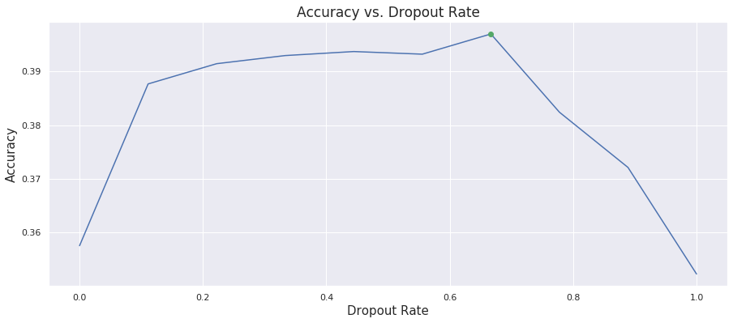

```python
def plot_dropout(dropout_parameters, accuracies, dropout_rate_optimal, accuracy_optimal):
    # Plot accuracies against dropout rate
    plt.figure(figsize = (15,6))
    plt.autoscale(True, axis = 'both')
    plt.ylabel('Accuracy', fontsize = 15)
    plt.xlabel('Dropout Rate', fontsize = 15)
    plt.title('Accuracy vs. Dropout Rate', fontsize = 17)
    plt.plot(dropout_parameters, accuracies)
    plt.plot(dropout_rate_optimal, accuracy_optimal, 'og')
    plt.show()

# Plot dropout rate
plot_dropout(dropout_parameters_i, accuracies_i, dropout_rate_optimal_i, accuracy_optimal_i)
```

When the drop out rate is zero, we simply get the accuracy of the model from before. The accuracy steadily increases with the drop out rate until an optimum value, then quickly decreasing as we approach 1, i.e. no outputs from a layer.

It makes sense that introducing drop out improves accuracy of the model on out of sample data, as its **forcing the active neurons to learn better and lower the error**. However if drop out rate is too high then there simply wont be enough neurons available to train the network effectively, which is why we see a drop off in accuracy as we approach 1.

We'll now run a finer grid search around our chosen value for the dropout rate. This wouldn't be necessary with more computational power where we could test the entire range to a sufficient degree of fineness, but this is a good approximate method to tune our dropout rate further in this situation.

```python
%%time
dropout_rate_optimal, accuracy_optimal, dropout_parameters, accuracies = tune_dropout_rate(
    start = dropout_rate_optimal_i - 0.15,
    end = dropout_rate_optimal_i + 0.15,
    fineness = 15,
    print_progress = True
    )
```

```
Dropout Rate = 0.517, Accuracy = 0.398
Dropout Rate = 0.538, Accuracy = 0.391
Dropout Rate = 0.560, Accuracy = 0.398
Dropout Rate = 0.581, Accuracy = 0.394
Dropout Rate = 0.602, Accuracy = 0.393
Dropout Rate = 0.624, Accuracy = 0.401
Dropout Rate = 0.645, Accuracy = 0.394
Dropout Rate = 0.667, Accuracy = 0.392
Dropout Rate = 0.688, Accuracy = 0.391
Dropout Rate = 0.710, Accuracy = 0.398
Dropout Rate = 0.731, Accuracy = 0.393
Dropout Rate = 0.752, Accuracy = 0.387
Dropout Rate = 0.774, Accuracy = 0.393
Dropout Rate = 0.795, Accuracy = 0.392
Dropout Rate = 0.817, Accuracy = 0.391
CPU times: user 11min 30s, sys: 24.8 s, total: 11min 54s
Wall time: 12min 7s
```

```python
print('Optimal Dropout Rate = %.3f'%(dropout_rate_optimal))
print('Optimal Accuracy = %.3f'%(accuracy_optimal))
```

```
Optimal Dropout Rate = 0.624
Optimal Accuracy = 0.401
```

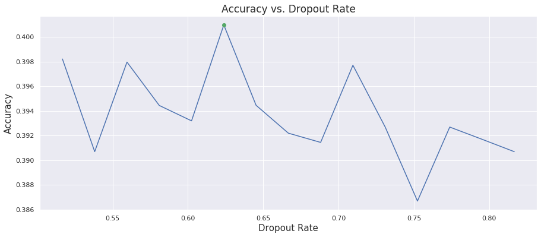

```python
# Plot dropout rate
plot_dropout(dropout_parameters, accuracies, dropout_rate_optimal, accuracy_optimal)
```

The above plot shows us that our choice of dropout rate actually becomes less obvious on this smaller scale, and it is perhaps due to chance that we get this particular optimal value due to the erratic changes in accuracy.

However, we've reached a slightly better accuracy for this dropout rate compared to our coarse search.

### Optimal Model Selection

Now we have a final network using our tuned drop out rate. This model is what we'll use in Task 4.

```python
# Set up optimal parameters
batch_size_optimal = batch_size
learning_rate_optimal = learning_rate
```

```python
%%time
# Get the optimal network
losses_optimal, accuracies_optimal, network_optimal = get_trained_neural_network(
    batch_size = batch_size_optimal,
    learning_rate = learning_rate_optimal,
    dropout_rate = dropout_rate_optimal,

    # Now turn split and test on so that we can observe the in-sample accuracy for these parameters
    split_and_test = True
)
```

```
CPU times: user 10.4 s, sys: 338 ms, total: 10.8 s
Wall time: 11 s
```

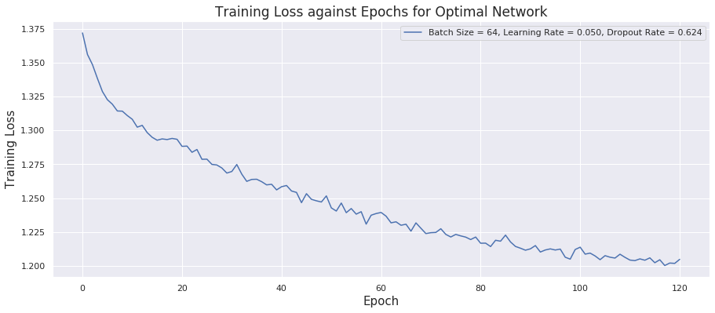

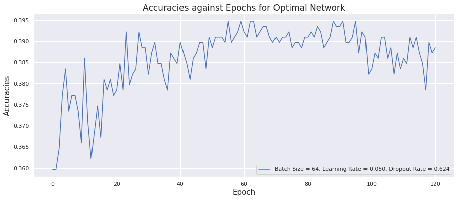

```python
# Plot losses against epochs for the final network
plot_stats(
    [losses_optimal],
    ['Batch Size = %d, Learning Rate = %.3f, Dropout Rate = %.3f'%(batch_size_optimal, learning_rate_optimal, dropout_rate_optimal)],
    'Training Loss against Epochs for Optimal Network',
    'Training Loss'
    )

plot_stats(
    [accuracies_optimal],
    ['Batch Size = %d, Learning Rate = %.3f, Dropout Rate = %.3f'%(batch_size_optimal, learning_rate_optimal, dropout_rate_optimal)],
    'Accuracies against Epochs for Optimal Network',
    'Accuracies'
    )
```

The above plots are less smooth than for our base network with no dropout, but this is leading to a higher final accuracy for our model. The training loss also indicates a fast enough rate of convergence to use with the testing data in task 4.

## Task 4: Discussion

### Introduction

In this task I'll compare the models that we've built in Tasks 1, 2, and 3 by applying them to the test data set.

```python
from sklearn.metrics import classification_report
from sklearn.metrics import confusion_matrix
```

```python
target_names = ['Unacceptable', 'Acceptable', 'Good', 'Very Good']
```

```python
%%time
y_pred_rf = rf_classifier_optimal.predict(descriptors_test)
class_report_rf = classification_report(target_test, y_pred_rf, target_names = target_names)
conf_matrix_rf = confusion_matrix(target_test, y_pred_rf)
```

```
CPU times: user 12.8 ms, sys: 0 ns, total: 12.8 ms
Wall time: 13.8 ms
```

```python
%%time
y_pred_svc = svc_classifier_optimal.predict(descriptors_test)
class_report_svc = classification_report(target_test, y_pred_svc, target_names = target_names)
conf_matrix_svc = confusion_matrix(target_test, y_pred_svc)
```

```
CPU times: user 119 ms, sys: 1.92 ms, total: 121 ms
Wall time: 123 ms
```

```python
%%time
test_loader = get_test_loader_from_arrays(batch_size_optimal, descriptors_test, target_test)
y_pred_nn, _ = neural_network_predict(network_optimal, test_loader)
class_report_nn = classification_report(target_test, y_pred_nn, target_names = target_names)
conf_matrix_nn = confusion_matrix(target_test, y_pred_nn)
```

```
CPU times: user 20.8 ms, sys: 2.96 ms, total: 23.7 ms
Wall time: 25 ms
```

### Task 4.1.1 - Classification Reports

In this section we'll consider the accuracy, recall, precision and F1 score of the models.

```python
print('Classification Report --- Random Forest')
print(class_report_rf)
print('Classification Report --- Support Vector Machine')
print(class_report_svc)
print('Classification Report --- Neural Network')
print(class_report_nn)
```

```
Classification Report --- Random Forest
              precision    recall  f1-score   support

Unacceptable       0.70      0.82      0.76       412
  Acceptable       0.45      0.21      0.29       188
        Good       0.46      0.46      0.46       204
   Very Good       0.51      0.59      0.54       188

    accuracy                           0.59       992
   macro avg       0.53      0.52      0.51       992
weighted avg       0.57      0.59      0.57       992

Classification Report --- Support Vector Machine
              precision    recall  f1-score   support

Unacceptable       0.70      0.83      0.75       412
  Acceptable       0.54      0.28      0.37       188
        Good       0.51      0.48      0.49       204
   Very Good       0.52      0.59      0.55       188

    accuracy                           0.60       992
   macro avg       0.56      0.54      0.54       992
weighted avg       0.59      0.60      0.59       992

Classification Report --- Neural Network
              precision    recall  f1-score   support

Unacceptable       0.71      0.79      0.75       412
  Acceptable       0.53      0.20      0.29       188
        Good       0.41      0.63      0.50       204
   Very Good       0.52      0.42      0.47       188

    accuracy                           0.58       992
   macro avg       0.54      0.51      0.50       992
weighted avg       0.58      0.58      0.56       992
```

#### *Accuracy*

Overall, all three of the models have an accuracy between 0.58 and 0.60, with the neural network performing the worst and the support vector machine the best. This level of accuracy indicates a good accuracy in classifying the cars, and there is **no significant difference between the models in terms of overall accuracy.**

As the difference in overall accuracy isn't statistically significant, we consider other scores to evaluate the performance of our models.

#### *Precision*

**All three models perform the best in terms of precision when it comes to classifying unacceptable cars**, with precision scores of 0.70, 0.70, and 0.71 for the random forest, the SVM, and the neural network respectively. **This means that a high proportion of cars that are given the label of unacceptable are indeed unacceptable.**

These scores are significantly higher than the weighted average precision of 0.57, 0.59 and 0.58 for the three models respectively. This is likely due to the fact that in reality, **the classification of unacceptability is the only negative classification, and that these cars will only be given this rating if they are particularly poor**. Whereas all the other ratings are positive. Therefore, the models all become good at classifying cars as unacceptable due to this obvious difference between good and bad ratings.

A notable difference between the three models is that the **random forest is considerably less precise in labelling acceptable cars compared to the other two models**, with a precision score of 0.45 compared to 0.54 and 0.53 for the other two models. This may be due to the fact that the random forest is the simplest process with the most straightforward training mechanism, whereas for the neural network in particular there are many more hyperparameters that we can tune.

Furthermore, the **neural network is less precise than the other two models when labelling good cars**, with a precision score of 0.41, compared to 0.46 for the random forest and 0.51 for the SVM. There is a significant difference between the neural network and the SVM in this instance.

#### *Recall*

The **models all perform particularly badly when it comes to the recall score of acceptable cars**, with recall scores of 0.21, 0.28 and 0.20 for the random forest, SVM and neural network models respectively. This means that **the models rarely find a high proportion of the true acceptable cars**. This may be due to the fact that once a car starts showing characteristics that take it away from the rating of good or very good, then the models automatically assume that it's an unacceptable car instead of the slightly more subtle classification of acceptable.

**These models are terrible if they're used to retrieve as many acceptable cars as possible from a data set**, in particular for the random forest and neural network models.

The **neural network performs better than the other two models in terms of sensitivity to good cars**, with a recall score of 0.63 compared to the average score of 0.47 for the other two models. This shows that the neural network is better optimised for retrieving good cars from a data set, perhaps due to its more complicated framework and weight optimisation process. This may lead to a model that can better distinguish between negative characteristics that lead to a rating of unacceptable or acceptable and good characteristics.

#### *F1 Score*

The F1 score is a summary statistic of both precision and recall, giving more weight to the lower value.

As previously seen, **all three models have very low F1 scores for acceptable cars due to poor recall**. The SVM model performs slightly better with a score of 0.37 compared to 0.29 for both the neural network and the random forest.

**All three models have a high F1 score for unacceptable cars** due to high scores for both recall and precision, with scores of 0.76, 0.75 and 0.75 for the random forest, SVM and neural network respectively. As previously discussed this may be due to unacceptable cars having very distinct characteristics, with this class being the only truly negative class.

The high performance in precision for labelling unacceptable cars may also be due to the higher number of unacceptable cars in the data set, with a support of 412 compared to 188, 204 and 188 for acceptable, good and very good cars. This gives the models a slightly disproportionately high number of unacceptable cars to work with.

### Task 4.1.2 - Confusion Matrices

In this section we'll reinterpret some of our results in the form of a confusion matrix, which displays more intuitively what the models are labelling different inputs.

In particular on the diagonal, high values, which correspond to lighter colours, correspond to correct labelling of descriptors. So, a perfect model would give a confusion matrix with black boxes outside of the diagonal.

```python
def conf_matrix_heatmap(conf_matrix, title):
    plt.figure(figsize = (6, 6))
    plt.title(title)
    sns.heatmap(conf_matrix)
    plt.xlabel('True Labels')
    plt.ylabel('Predicted Labels')
    plt.show()
```

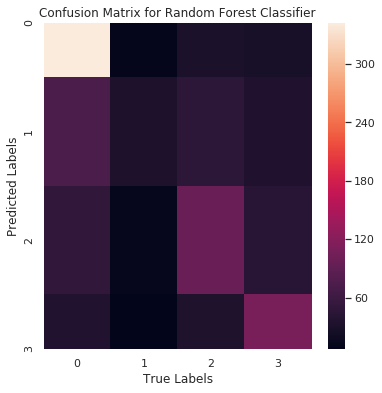

```python
conf_matrix_heatmap(conf_matrix_rf, 'Confusion Matrix for Random Forest Classifier')
```

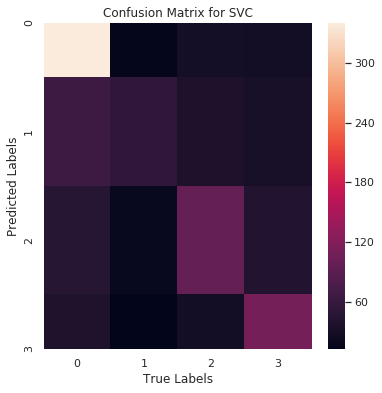

```python
conf_matrix_heatmap(conf_matrix_svc, 'Confusion Matrix for SVC')
```

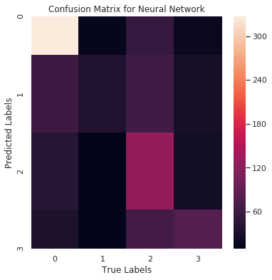

```python
conf_matrix_heatmap(conf_matrix_nn, 'Confusion Matrix for Neural Network')
```

The confusion matrices show how many of each classed car are being given each rating.

As shown by our analysis of the classification reports, all three models have a very bright colour for (0, 0), indicating that **all three models are correctly labelling a high proportion of the unacceptable cars**. However note that the confusion matrices are not normalising to take into account the true number of each rating in the data set, which is why the colour in the top left is very bright - though from our previous discussion we know it would still be brighter than the other squares.

We can also see that (2, 2) has a considerably brighter colour for the neural network than for the other two models, showing that the **neural network is better than the other models at labelling good cars**.

### Task 4.1.3 - Further Methods

As previously discussed, recomputing the methods in Tasks 1, 2 and 3 with bootstrapped data may resolve the issue of low sensitivity to acceptable, good and very good cars when compared the recall score of unacceptable cars for all three models. If a bootstrapped data set produced similar results, then we'd know that it is inherently easier to spot unacceptable cars compared to cars that aren't unacceptable. If the recall rates for the not unacceptable ratings, then we'd know that there is no inherent difference, and that the models would be more useful for spotting cars of all ratings.

### Task 4.2 - Discussion

Now we'll examine the suitability of each of the models to the task.

#### *Generalisability*

All three models have an acceptable score for accuracy, and so they're performing well when generalised to new out of sample data. However with accuracy scores between 0.58 and 0.60, the models are still not performing that much higher than a model that is randomly classifying data. Therefore they're not at their full potential when it comes to generalisability. In this case, the SVM is slightly better than the other two as it has the highest accuracy score of 0.60.

In our models we were ensuring that we were selecting hyperparameters that prevented overfitting, i.e. ensuring that our models were working well on new data instead of just being able to fit with the data in the sample.

Our random forest classifier in particular is not susceptible to overfitting as we carefully selected the maximum depth by observing the training and testing accuracy scores during the tuning process.

#### *Computational Cost (Prediction)*

*Note that all times refer to the CPU processing time, assuming that the time to output a classification report and a confusion matrix is neglible. We also use processing time to consider computational cost instead of number of operations.*

The **most computationally expensive model is the SVM**, which took 121ms to give predictions for the test data, compared to 23.7ms for the neural network and 12.8ms for the random forest. This means that SVM is over five times slower than the fastest classifier at predicting outcomes. This is the downside that comes from being able to capture the complex relationships more accurately.

The low processing time for the random forest is expected as it is the simplest model in terms of training.

However, these prediction times are neglible, and shouldn't greatly influence what we consider to be the best model.

#### *Computational Cost (Training)*

As we saw in Task 3 for the neural network, the tuning of a single hyperparameter (dropout rate) with a range of 10 different values to test took just as long as it took the other two models to tune three or more hyperparameters with 6-10 possible values each.

Below is a summary of the CPU processing time for each of the initial coarse tuning processes:

Random Forest

- Total Combinations: 3300 total fits
- Total CPU Time: 10.8min
- Average Time per Fit: 0.196 s/fit

SVM

- Total Combinations: 665 total fits
- Total CPU Time: 7.6min
- Average Time per Fit: 0.686 s/fit

Neural Network

- Total Combinations: 10 fits
- Total CPU Time: 7min 51s
- Average Time per Fit: 47.1 s/fit

It is clear that the **neural network is computationally much more expensive than the other two models when tuning hyperparameters**, taking **over 240 times as long to fit a single model** than the random forest classifier.

#### *Dimensionality*

In general, neural networks can be optimised to deal with high-dimensionality, and SVM and random forests deal with lower dimensions. For example, neural networks are commonly used to classify images, for which each pixel is considered as a dimension.

For our data set, we're working in a low-level dimensionality of 6, and so the neural networks capability to deal with high-dimensionality data is not necessary.

### Final Recommendation

The model I'd recommend to the manager depends on the task that he wants to complete.

Due to the low-dimensionality of the data, the significantly higher computational complexity of training, and the neglible differences in accuracy scores when compared to other models, **I wouldn't recommend the neural network. I would only recommend it is if the manager prioritises accurately labelling good cars**, as the neural network is much better at this than the other two.

**If the manager wants to retrieve as many acceptable cars as possible from a data set, then I wouldn't recommend any of the models**, especially the neural network and the random forest classifier.

I would recommend the random forest if the priority was fast training and testing times, and if we didn't need to precisely label good cars.

Outside of these scenarios, **in general I would recommend the SVM**, in particular due to generalisability, and a good trade off between computational cost and weighted average F1 score.

## Task 5: Mastery

### Task 5.1 - Deep Neural Network

In this task we design a deep neural network that has additional layers of neurons and compare it to our base network without drop out layers, using the batch size of 64 and learning rate of 0.05.

```python
# Define the hyperparameters that we're gonna use in the following analysis
hidden_size_d = 80
```

```python
# Define the neural network with dropout
class NeuralNetDeep(nn.Module):
    def __init__(self, input_size, hidden_size_d, num_classes):
        super(NeuralNetDeep, self).__init__()

        self.start = nn.Linear(input_size, hidden_size_d)
        self.middle = nn.Linear(hidden_size_d, hidden_size_d)
        self.end = nn.Linear(hidden_size_d, num_classes)

    def forward(self, x):
        # Use ReLU as the activation function

        # Apply ReLU to x
        x = F.relu(self.start(x))

        x = F.relu(self.middle(x))
        x = F.relu(self.middle(x))
        x = F.relu(self.middle(x))
        x = F.relu(self.middle(x))

        x = self.end(x)

        # No final softmax as it's included in CrossEntropyLoss
        return x
```

#### Example of a Deep Neural Network

```python
# Create instance of the deep network
network_deep = NeuralNetDeep(input_size, hidden_size_d, num_classes)
```

```python
%%time
# Train the network
loss_deep, accuracies_deep, network_deep = neural_network_training(network_deep, print_loss_values = False, split_and_test = True)
```

```
CPU times: user 10.3 s, sys: 304 ms, total: 10.6 s
Wall time: 10.7 s
```

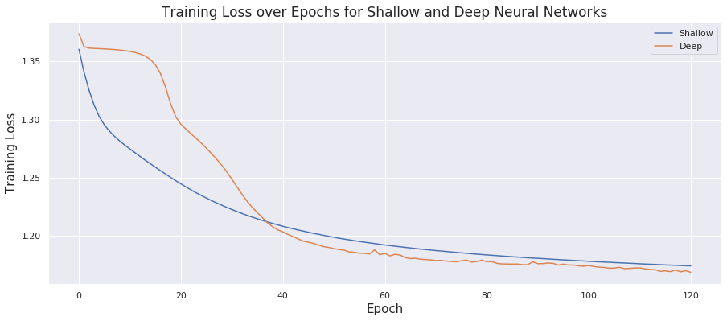

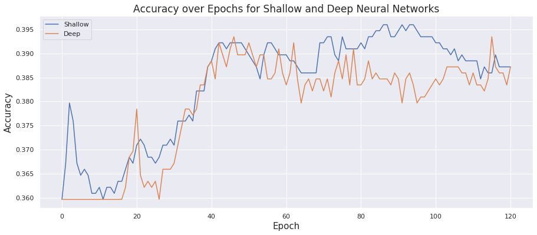

```python
# Plot training loss and accuracy
plot_stats([loss_base, loss_deep], ['Shallow', 'Deep'], 'Training Loss over Epochs for Shallow and Deep Neural Networks', 'Training Loss')
plot_stats([accuracies_base, accuracies_deep], ['Shallow', 'Deep'], 'Accuracy over Epochs for Shallow and Deep Neural Networks', 'Accuracy')
```

The deep neural network initially trains at a slower rate, shown by a slower decrease in training loss and a flat line for the accuracy until around 20 epochs, but then trains at a faster rate than the shallow network between 20 and 40 epochs. This is due to a higher number of parameters that we can tune within the network to allow for faster training after initial set up.

The initial set up required does however means that the accuracy will stay consistent for longer, instead of the initial improvements we see in the shallow network. Also note that the in-sample accuracy of both networks is very similar after approximately 40 epochs, but that the deep neural network reaches a lower training loss and a slightly lower accuracy at the end. Between 80 and 100 epochs the deep neural network does also dip in accuracy when compared to the base network.

The in-sample accuracy of the deep neural network is also considerably more erratic after 40 epochs, with sharp jumps and high variability. The training loss also has some jumps upwards instead of always decreasing, which may be due to the tuning of a higher number of neurons adding a higher amount of variability between epochs.

The deep neural network has similar computational cost to the shallow neural network in terms of training over 120 epochs, taking up a similar amount of CPU time. However, the number of operations will be considerably higher.

In general, with a well set up architecture deep neural networks can achieve better results than shallow ones, and this is due to the intermediate hidden layers being able to bring out more characteristics of the data.